# Ejercicio práctico desarrollo modelo de credit scoring

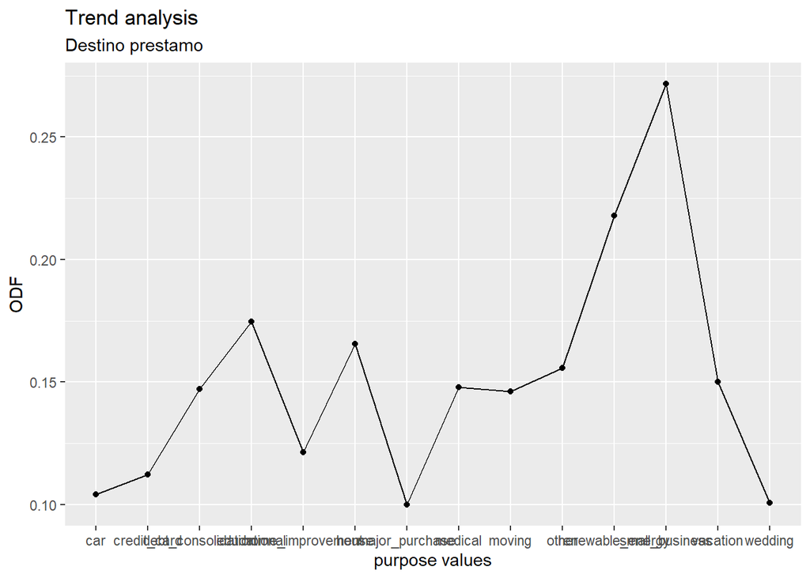

```r
trends("purpose","Destino prestamo")
```

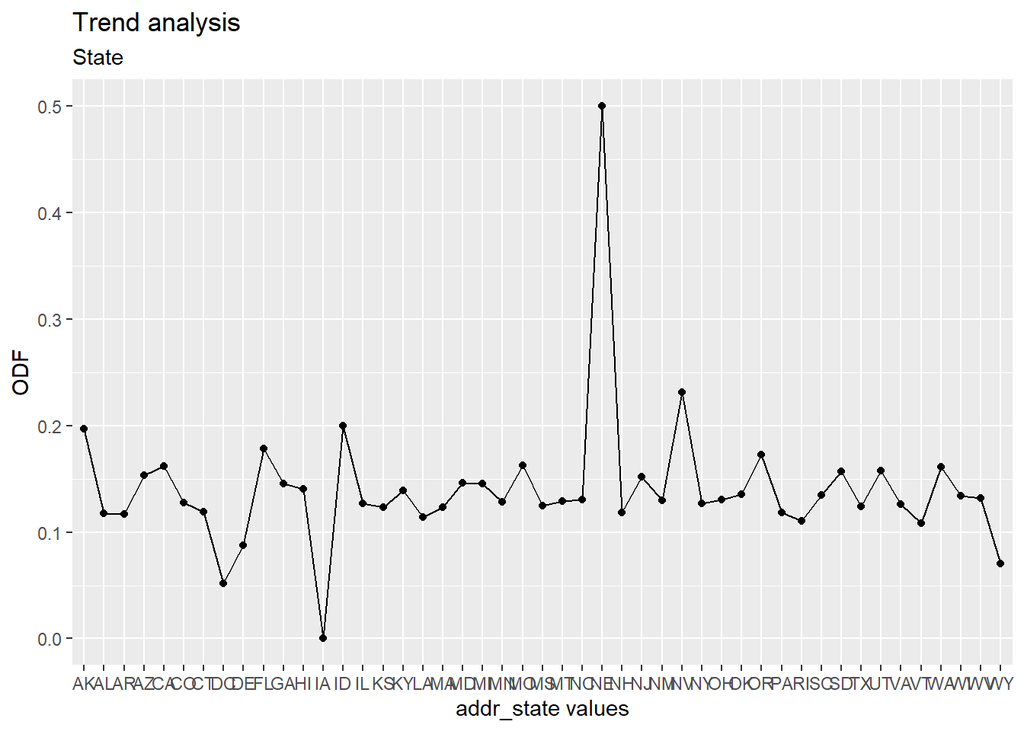

```r
trends("addr_state","State")
```

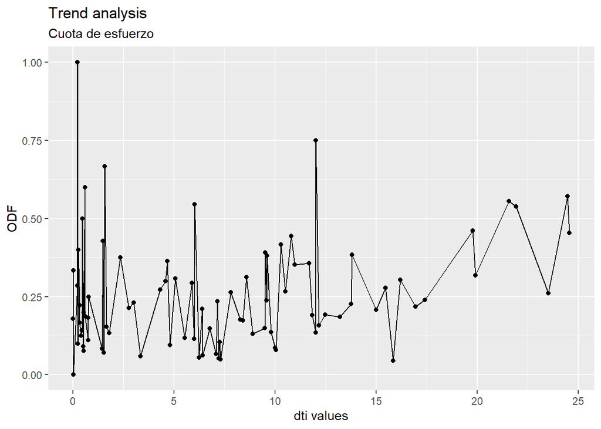

```r
trends("dti","Cuota de esfuerzo")
```

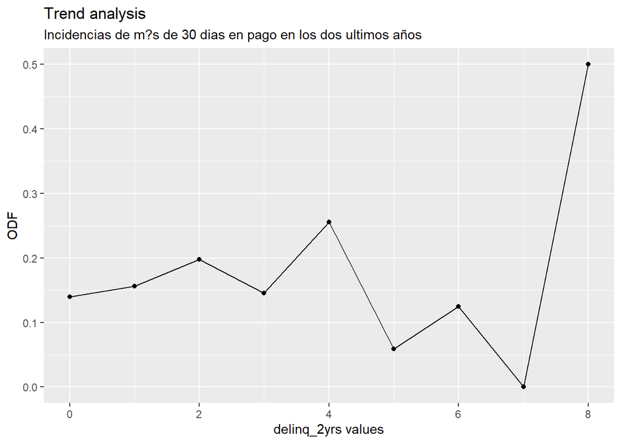

```r
trends("delinq_2yrs","Incidencias de m?s de 30 dias en pago en los dos ultimos años")
```

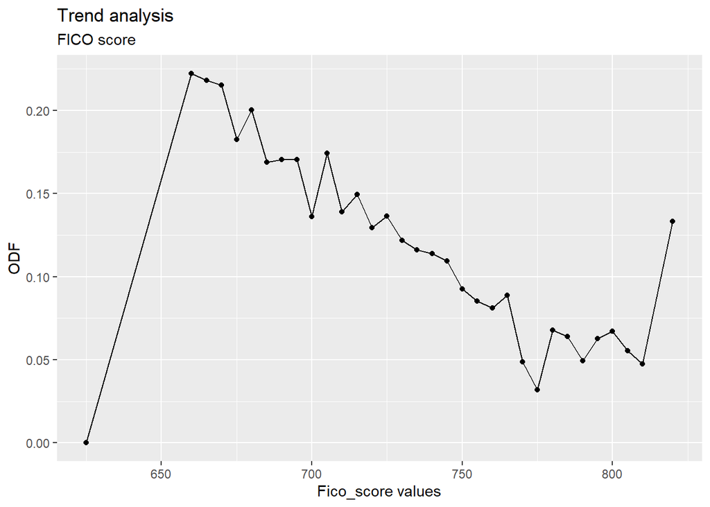

```r
trends("Fico_score","FICO score")
```

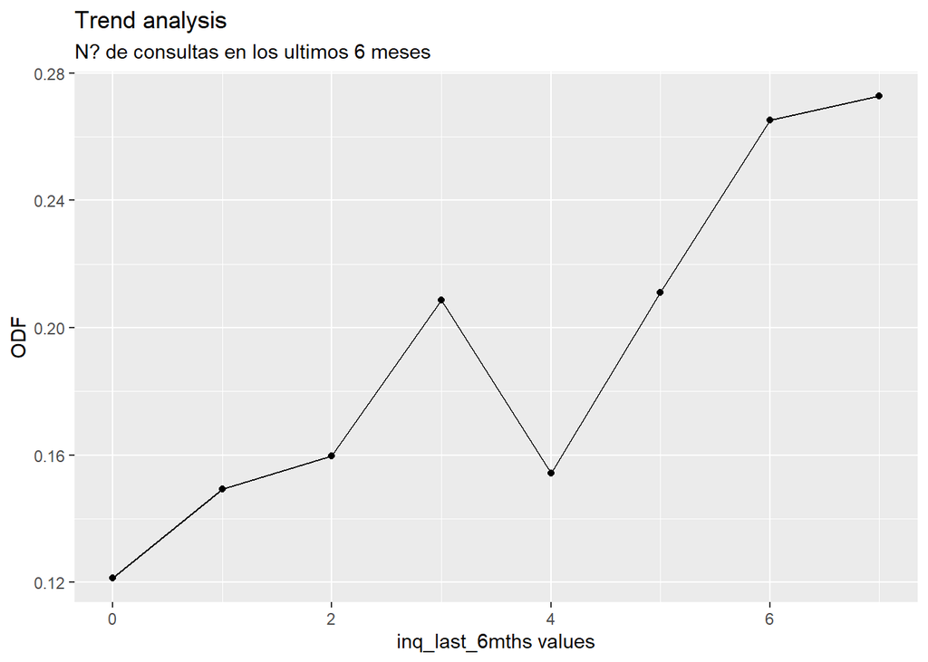

```r
trends("inq_last_6mths","N? de consultas en los ultimos 6 meses")
```

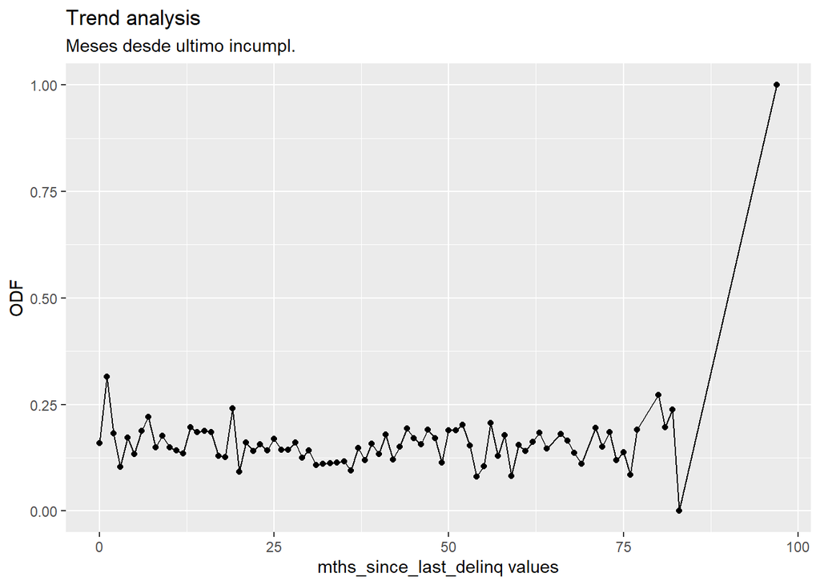

```r
trends("mths_since_last_delinq","Meses desde ultimo incumpl.")
```

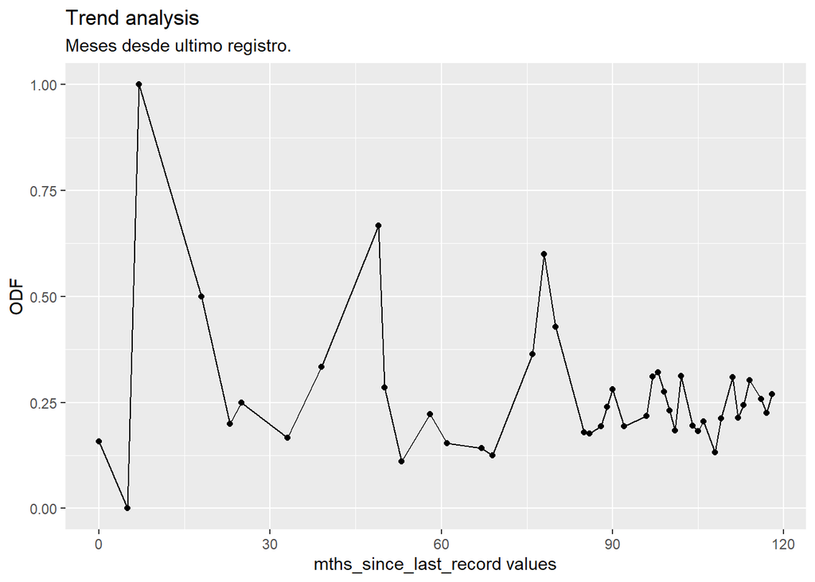

```r
trends("mths_since_last_record","Meses desde ultimo registro.")
```

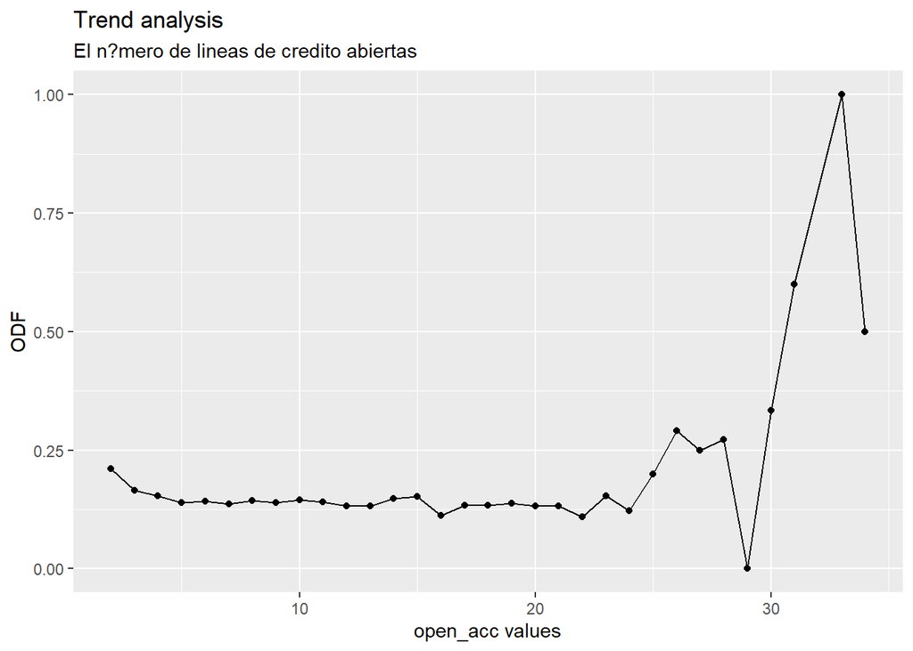

```r
trends("open_acc","El n?mero de lineas de credito abiertas ")
```

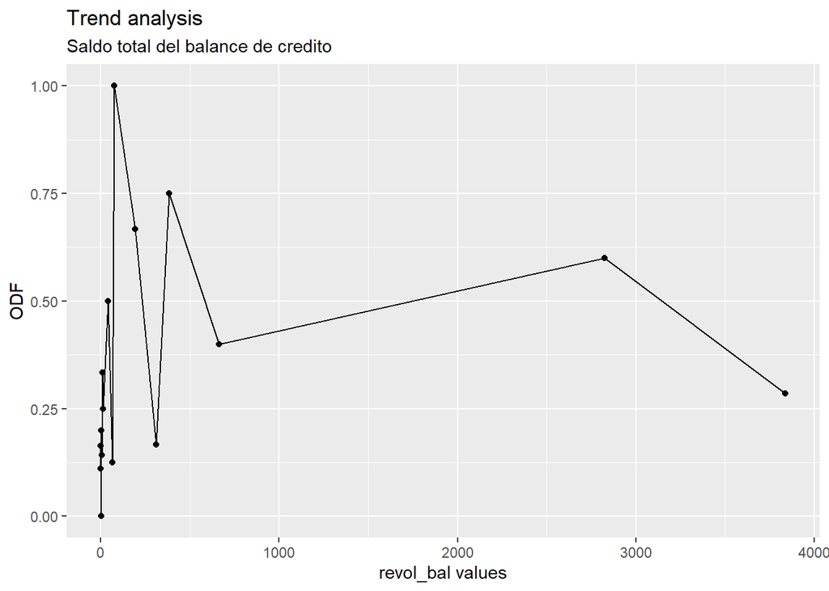

```r
trends("revol_bal","Saldo total del balance de credito")
```

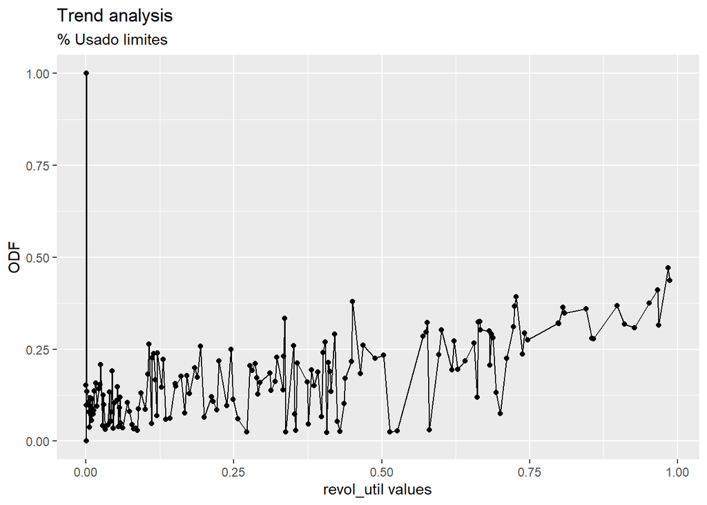

```r
trends("revol_util","% Usado limites")
```

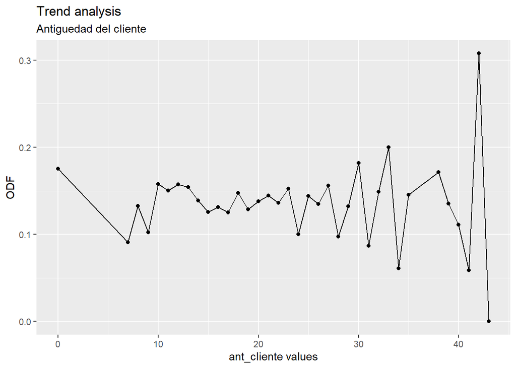

```r
trends("ant_cliente","Antiguedad del cliente")
```

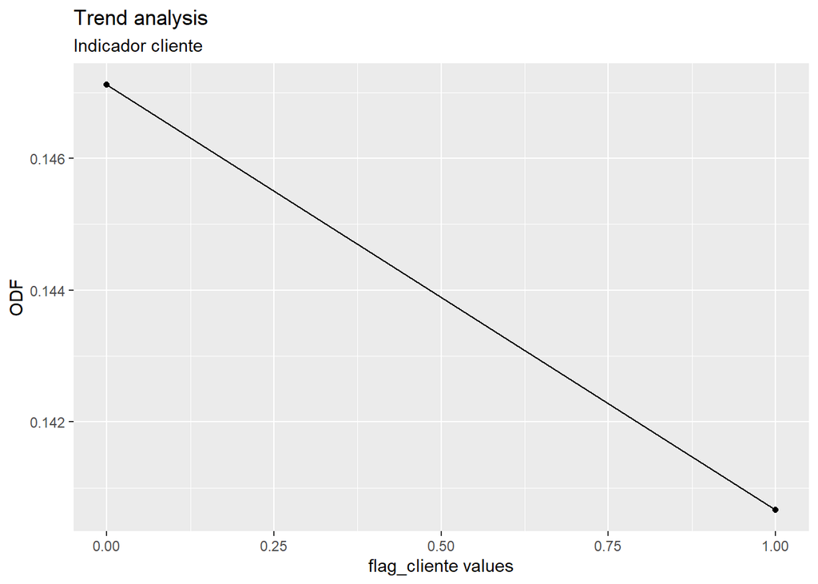

```r
trends("flag_cliente","Indicador cliente")
```

Otra manera de realizar el análisis es realizar gráficos de densidad para clientes “buenos” y “malos” en un único grafico para cada variable. Es decir, analizar gráficamente que valores toma cada variable para cada tipo de cliente. Vamos a hacerlo sobre las variables numéricas únicamente:

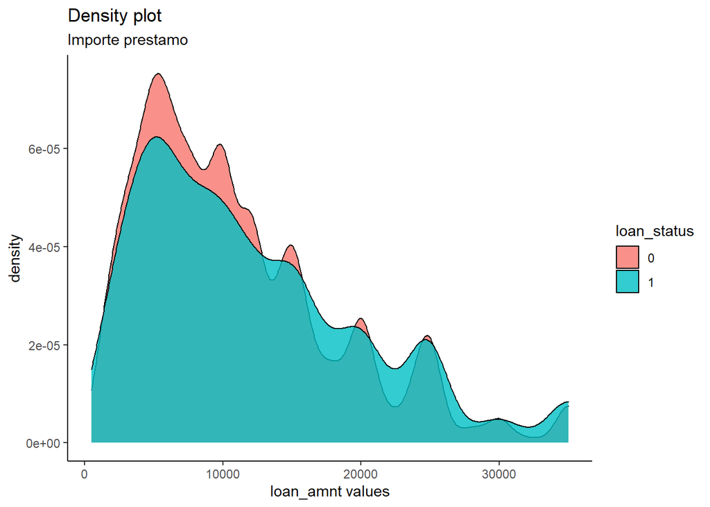

```r
library(ggplot2)
theme_set(theme_classic())


#loan_amnt

ggplot(train, aes((loan_amnt))) + geom_density(aes(fill=factor(loan_status)),alpha=0.8) +
    labs(title="Density plot",
         subtitle="Importe prestamo",
         x=paste("loan_amnt values",sep=''),
         fill="loan_status")
```

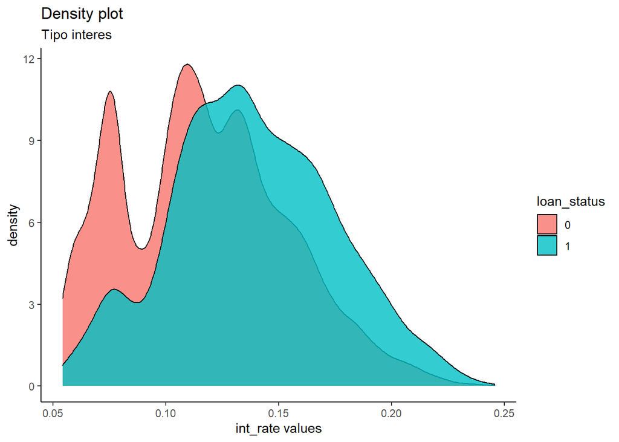

```r
#int_rate

ggplot(train, aes((int_rate))) + geom_density(aes(fill=factor(loan_status)),alpha=0.8) +
    labs(title="Density plot",
         subtitle="Tipo interes",
         x=paste("int_rate values",sep=''),
         fill="loan_status")
```

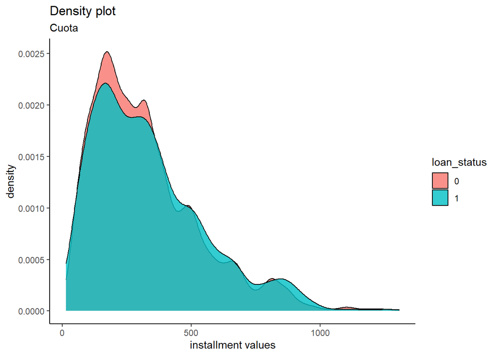

```r
#installment

ggplot(train, aes((installment))) + geom_density(aes(fill=factor(loan_status)),alpha=0.8) +
    labs(title="Density plot",
         subtitle="Cuota",
         x=paste("installment values",sep=''),
         fill="loan_status")
```

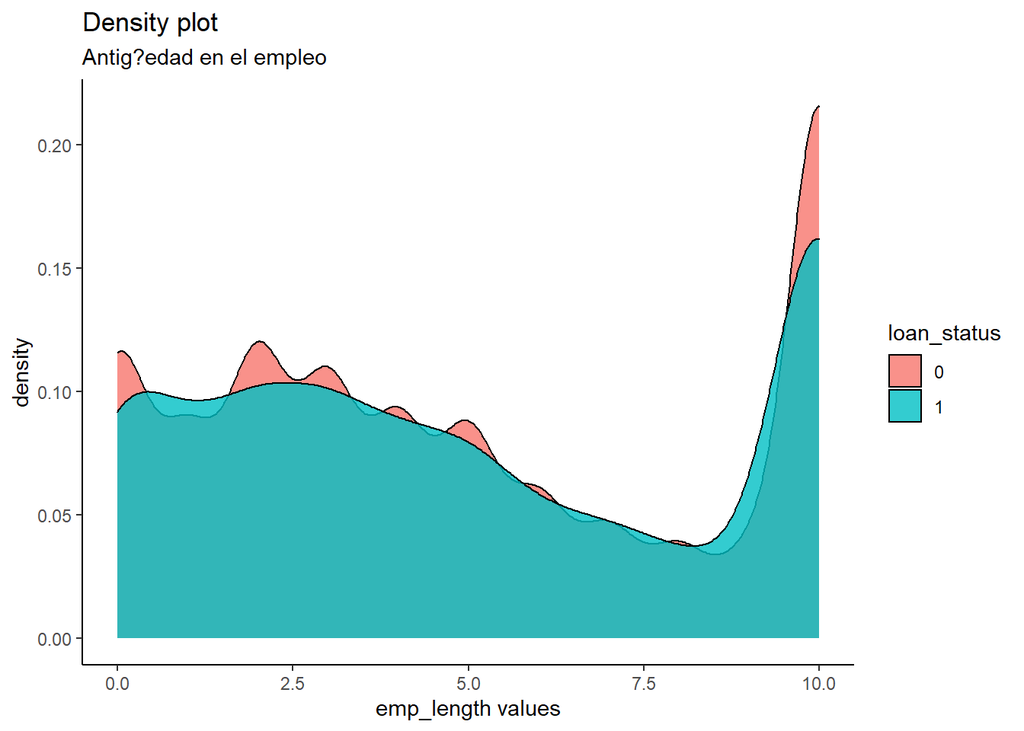

```r
#emp_length

ggplot(train, aes((emp_length))) + geom_density(aes(fill=factor(loan_status)),alpha=0.8) +
    labs(title="Density plot",
         subtitle="Antig?edad en el empleo",
         x=paste("emp_length values",sep=''),
         fill="loan_status")
```

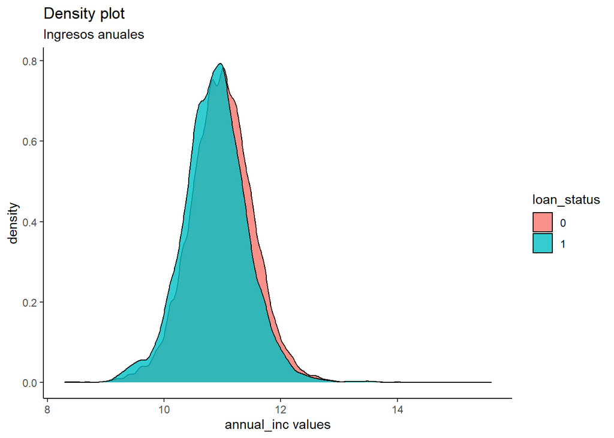

```r
#anual_inc

ggplot(train, aes(log(annual_inc))) + geom_density(aes(fill=factor(loan_status)),alpha=0.8) +
    labs(title="Density plot",
         subtitle="Ingresos anuales",
         x=paste("annual_inc values",sep=''),
         fill="loan_status")
```

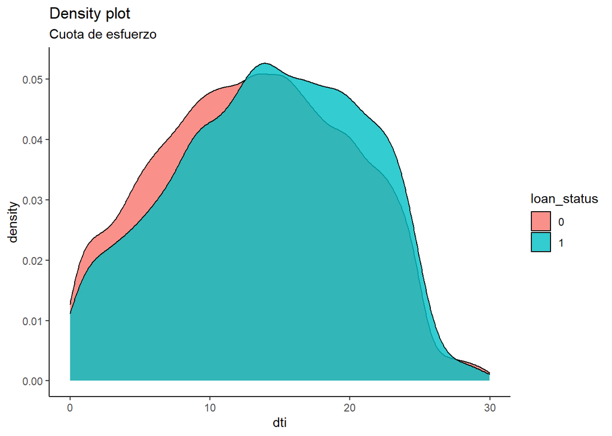

```r
#dti

ggplot(train, aes((dti))) + geom_density(aes(fill=factor(loan_status)),alpha=0.8) +
    labs(title="Density plot",
         subtitle="Cuota de esfuerzo",
         x=paste("dti",sep=''),
         fill="loan_status")
```

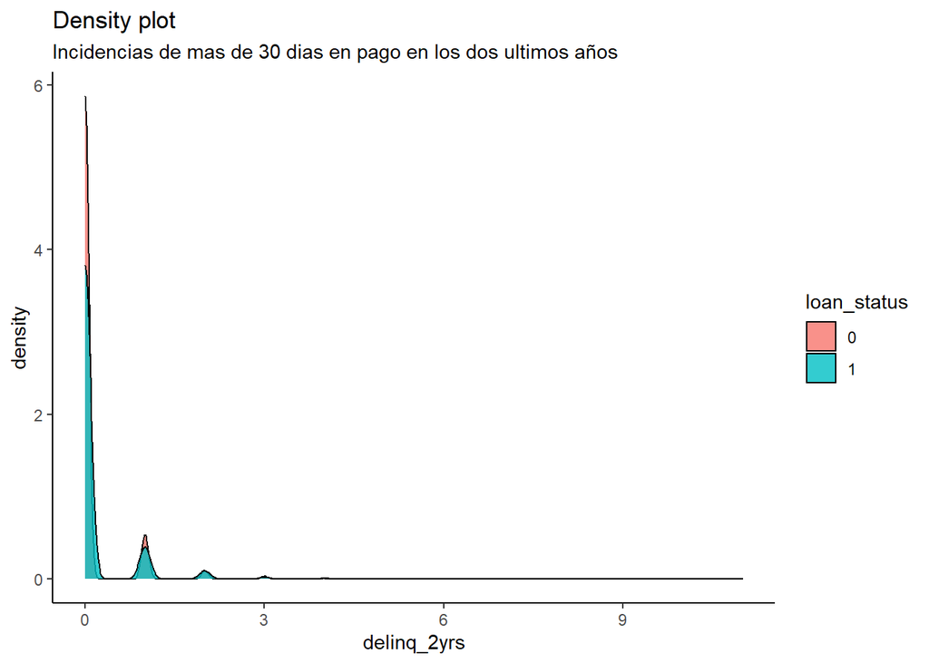

```r
#delinq_2yrs

ggplot(train, aes((delinq_2yrs))) + geom_density(aes(fill=factor(loan_status)),alpha=0.8) +
    labs(title="Density plot",
         subtitle="Incidencias de mas de 30 dias en pago en los dos ultimos años",
         x=paste("delinq_2yrs",sep=''),
         fill="loan_status")
```

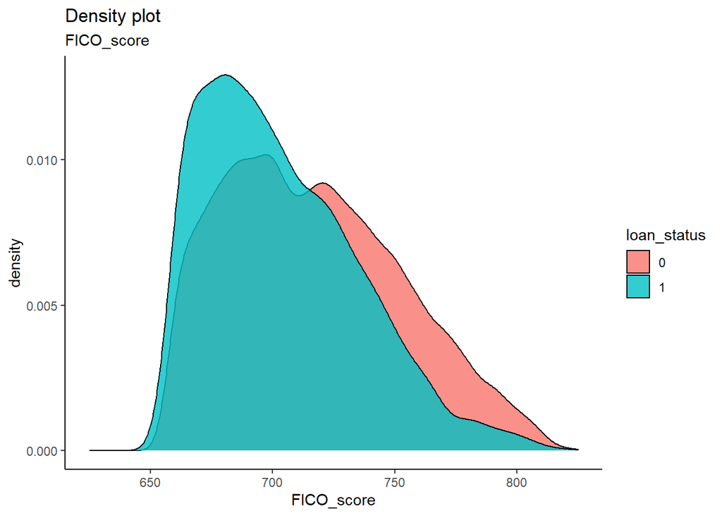

```r
#FICO_score

ggplot(train, aes((Fico_score))) + geom_density(aes(fill=factor(loan_status)),alpha=0.8) +
    labs(title="Density plot",
         subtitle="FICO_score",
         x=paste("FICO_score",sep=''),
         fill="loan_status")
```

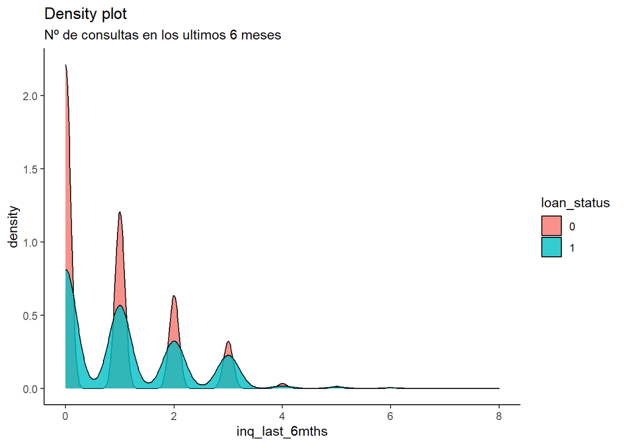

```r
#inq_last_6mths

ggplot(train, aes((inq_last_6mths))) + geom_density(aes(fill=factor(loan_status)),alpha=0.8) +
    labs(title="Density plot",
         subtitle="Nº de consultas en los ultimos 6 meses",
         x=paste("inq_last_6mths",sep=''),
         fill="loan_status")
```

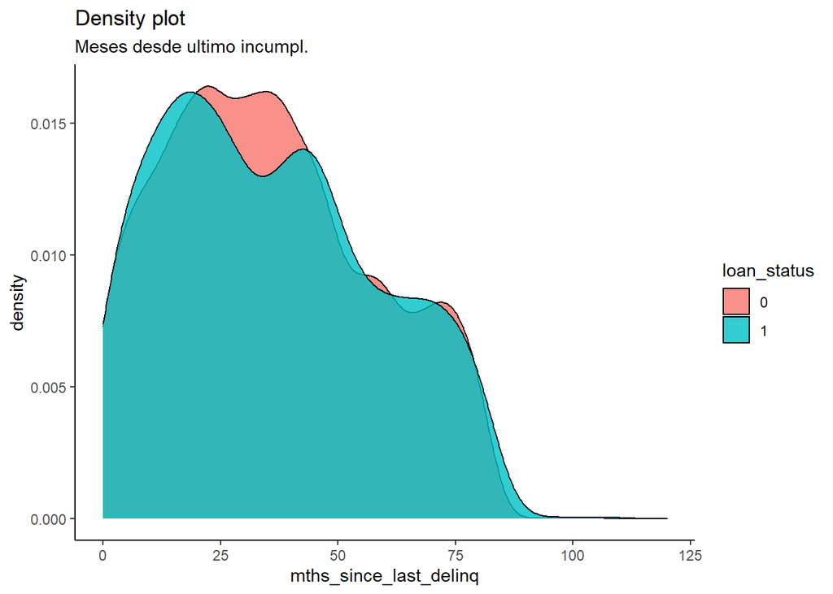

```r
#mths_since_last_delinq

ggplot(train, aes((mths_since_last_delinq))) + geom_density(aes(fill=factor(loan_status)),alpha=0.8) +
    labs(title="Density plot",
         subtitle="Meses desde ultimo incumpl.",
         x=paste("mths_since_last_delinq",sep=''),
         fill="loan_status")
```

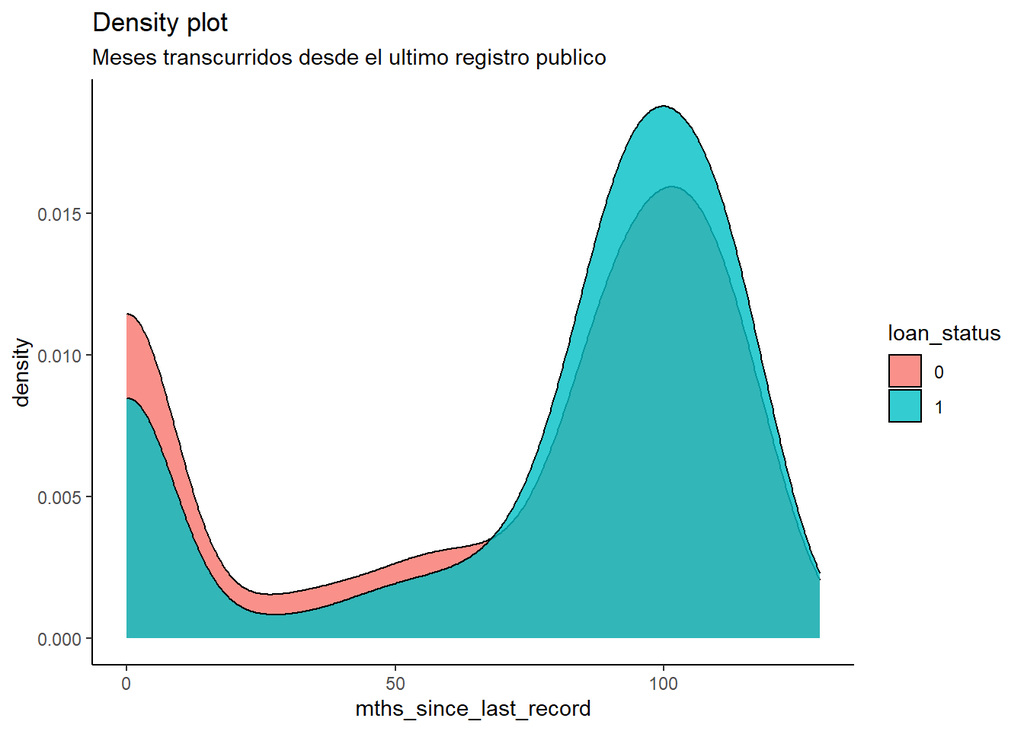

```r
#mths_since_last_record

ggplot(train, aes((mths_since_last_record))) + geom_density(aes(fill=factor(loan_status)),alpha=0.8) +
    labs(title="Density plot",
         subtitle="Meses transcurridos desde el ultimo registro publico",
         x=paste("mths_since_last_record",sep=''),
         fill="loan_status")
```

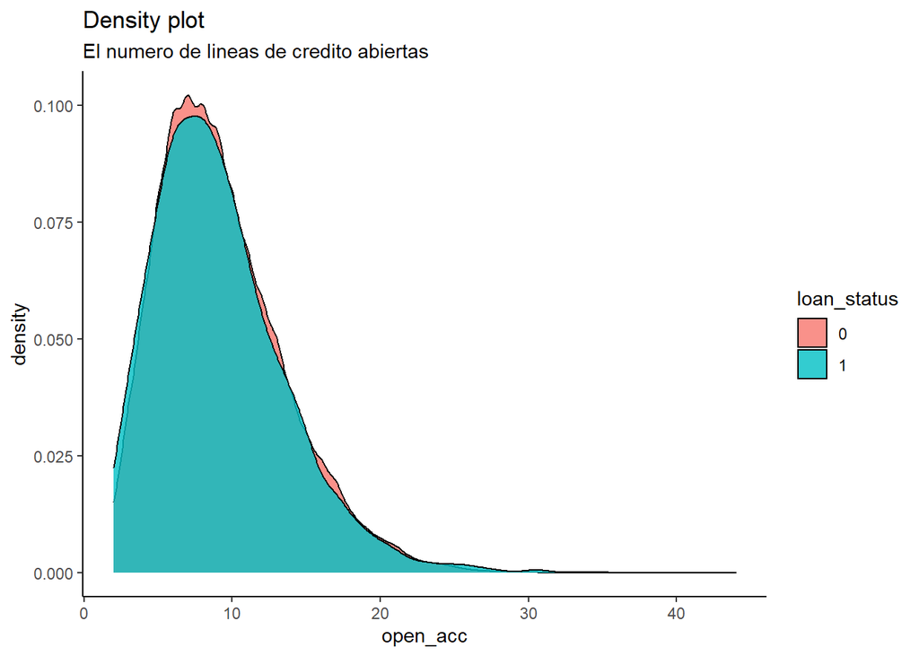

```r
#open_acc

ggplot(train, aes((open_acc))) + geom_density(aes(fill=factor(loan_status)),alpha=0.8) +
    labs(title="Density plot",
         subtitle="El numero de lineas de credito abiertas",
         x=paste("open_acc",sep=''),
         fill="loan_status")
```

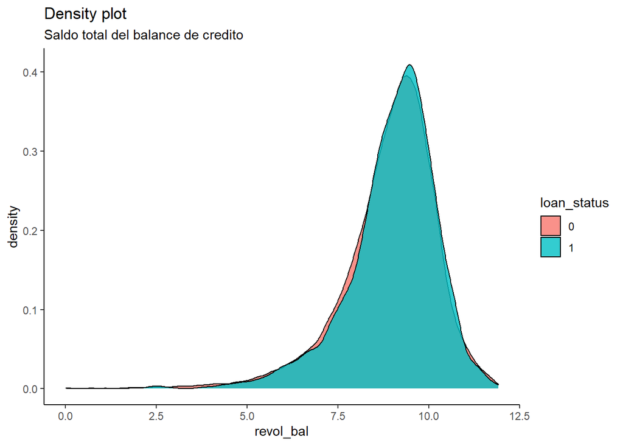

```r
#revol_bal

ggplot(train, aes(log(revol_bal))) + geom_density(aes(fill=factor(loan_status)),alpha=0.8) +
    labs(title="Density plot",
         subtitle="Saldo total del balance de credito",
         x=paste("revol_bal",sep=''),
         fill="loan_status")
```

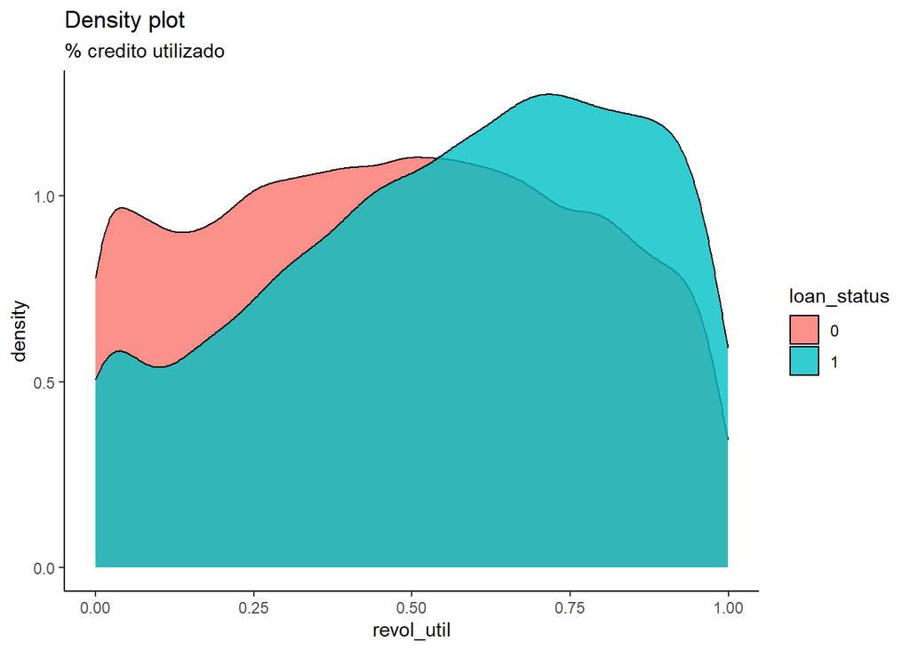

```r
#revol_util

ggplot(train, aes((revol_util))) + geom_density(aes(fill=factor(loan_status)),alpha=0.8) +
    labs(title="Density plot",
         subtitle="% credito utilizado",
         x=paste("revol_util",sep=''),
         fill="loan_status")
```

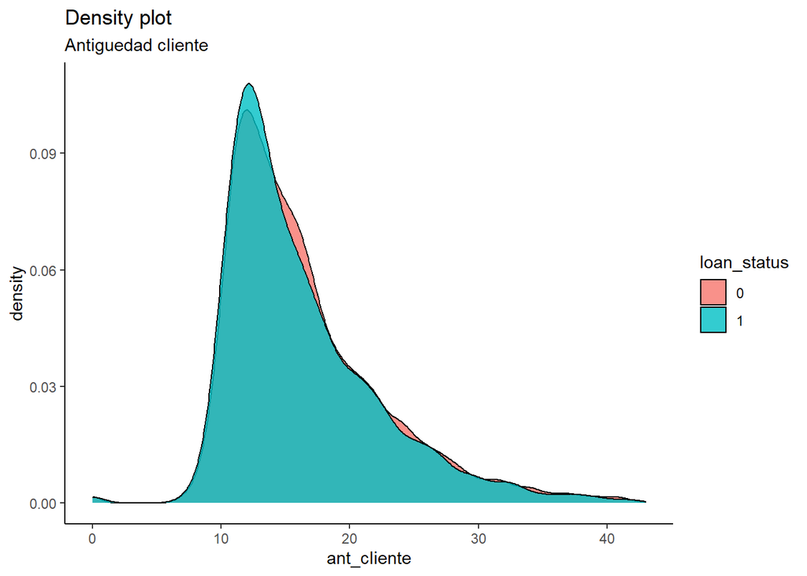

```r
#ant_cliente

ggplot(train, aes((ant_cliente))) + geom_density(aes(fill=factor(loan_status)),alpha=0.8) +
    labs(title="Density plot",
         subtitle="Antiguedad cliente",
         x=paste("ant_cliente",sep=''),
         fill="loan_status")
```

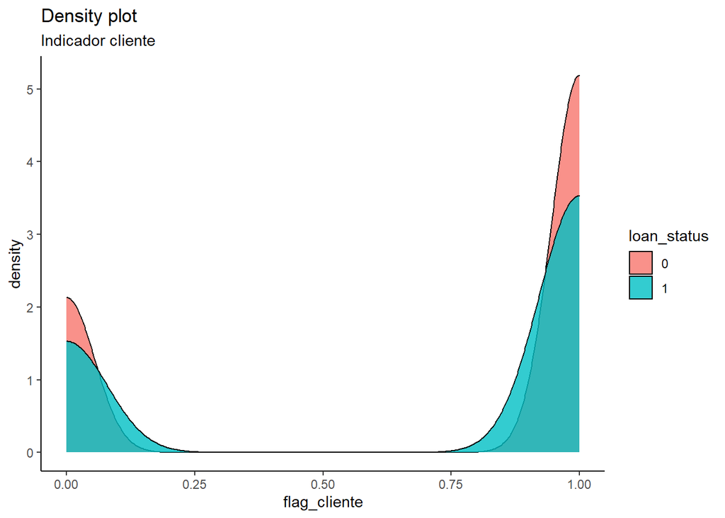

```r
#flag_cliente

ggplot(train, aes((flag_cliente))) + geom_density(aes(fill=factor(loan_status)),alpha=0.8) +
    labs(title="Density plot",
         subtitle="Indicador cliente",
         x=paste("flag_cliente",sep=''),
         fill="loan_status")
```

```r
save.image("Backup3.RData")
```

De los gráficos anteriores podemos ver como hay algunas variables como el Fico score o el tipo de interés que parecen separar mejor a los clientes buenos y malos.

EJERCICIO 3: AGRUPACIÓN DE VARIABLES

Vamos a medir analiticamente cuál es la capacidad o poder discriminante de cada variable. Para usar el paquete que nos calcula el poder discriminante de las variables, es necesario considerar el default o el loan_status al revés de lo que lo habiamos hecho, es decir un 0 si el préstamo resulto impagado y 1 en caso contrario:

```r
source("woe_functions.R")

train$Default2<-as.numeric(as.character(train$loan_status))
train$Default2<-as.numeric(ifelse(train$Default2==1,0,1))
test$Default2<-as.numeric(as.character(test$loan_status))
test$Default2<-as.numeric(ifelse(test$Default2==1,0,1))
```

Primero calculamos el poder predictivo de las variables numéricas:

[output not shown]

```
##                      Char     IV               Process
## 3                int_rate 0.3564    Numeric binning OK
## 10             Fico_score 0.1687    Numeric binning OK
## 16             revol_util 0.0904    Numeric binning OK
## 6              annual_inc 0.0416    Numeric binning OK
## 11         inq_last_6mths 0.0402    Numeric binning OK
## 2               loan_amnt 0.0251    Numeric binning OK
## 8                     dti 0.0208    Numeric binning OK
## 1                      id 0.0105    Numeric binning OK
## 4             installment 0.0098    Numeric binning OK
## 17            ant_cliente 0.0042    Numeric binning OK
## 9             delinq_2yrs 0.0033    Numeric binning OK
## 5              emp_length     NA No significant splits
## 7             loan_status     NA    Uniques values < 5
## 12 mths_since_last_delinq     NA No significant splits
## 13 mths_since_last_record     NA No significant splits
## 14               open_acc     NA No significant splits
## 15              revol_bal     NA No significant splits
## 18           flag_cliente     NA    Uniques values < 5
```

El poder discriminante de cada variable teniendo en cuenta el IV se mide a través de la siguiente guía:

Information Value Predictive Power < 0.02: useless for prediction 0.02 to 0.1: Weak predictor 0.1 to 0.3: Medium predictor 0.3 to 0.5: Strong predictor >0.5 Suspicious or too good to be true

De acuerdo a los valores que hemos calculado:

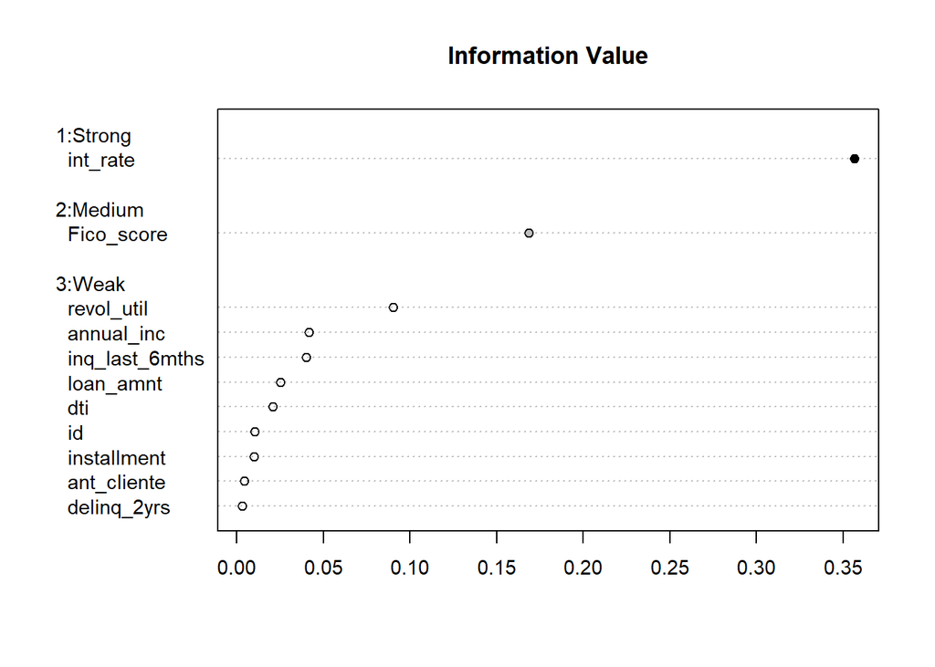

```r
smbinning.sumiv.plot(IV_numeric, cex = 0.9)
```

La variable con más poder predictivo es el tipo de interés aplicable a los préstamos. Esta variable no suele ser empleada en este tipo de modelos de scoring pues es muy dependiente de la política de concesión de préstamos de la entidad, situación económica….

Cuando la función anterior devuelve el valor: “No significant splits”, indica que la variable no permite discriminar nada los clientes con problemas en el pago de los que no, por lo tanto podremos descartar estas variables.

Una de las variables flag_cliente aparece con el mensaje “Uniques values of x < 5”. El paquete no realizara el calculo en valores numericos con menos de 5 valores unicos, ya que entiende que deberia ser casi una variable categorica:

```r
table(train$flag_cliente)
```

```
##
##     0     1
##  8157 19693
```

Vamos a tratar esta variable, convirtiéndola en categórica:

```r
train$flag_cliente<-as.factor(train$flag_cliente)
test$flag_cliente<-as.factor(test$flag_cliente)
```

Ahora calcularemos en poder predictivo de las variables categóricas (estas variables recordad que las tenemos creadas ya en el Ejercicio 1 de Exploración de Datos -línea aprox 446-).

Recordemos que tenemos una nueva variable categórica que acabamos de crear:

```r
categorical_vars<-c(categorical_vars,"flag_cliente")
```

Es necesario que las convirtamos en factor para el paquete:

NOTA IMPORTANTE: Para versiones de R anteriores a la 4.01 este código siguiente sí que funciona, En versiones posteriores da fallo así que lo haremos manualmente como se indica a continuación

```r
#
# for (m in 1:length(categorical_vars)){
#
#   var_name<-as.character(categorical_vars[m])
#   train[,var_name]<-as.factor(train[,var_name])
#   test[,var_name]<-as.factor(test[,var_name])
# }
#
```

Para versiones de R posteriores a 4.1 este código deberá utilizarse en lugar del anterior, ya que da fallo al parecer.

```r
#Train
train$term=as.factor(train$term)
train$grade=as.factor(train$grade)
train$emp_title=as.factor(train$emp_title)
train$home_ownership=as.factor(train$home_ownership)
train$verification_status=as.factor(train$verification_status)
train$desc=as.factor(train$desc)
train$purpose=as.factor(train$purpose)
train$addr_state=as.factor(train$addr_state)
train$flag_cliente=as.factor(train$flag_cliente)




#Test
test$term=as.factor(test$term)
test$grade=as.factor(test$grade)
test$emp_title=as.factor(test$emp_title)
test$home_ownership=as.factor(test$home_ownership)
test$verification_status=as.factor(test$verification_status)
test$desc=as.factor(test$desc)
test$purpose=as.factor(test$purpose)
test$addr_state=as.factor(test$addr_state)
test$flag_cliente=as.factor(test$flag_cliente)
```

NOTA: Para versiones superiores de R de 4.1 hay que referenciar la muestra train como as.data.frame() para que funcione el código. Como vemos mas abajo

Ahora calculemos el IV de estas variables:

```r
IV_cat<-matrix("NA",length(categorical_vars),2)
colnames(IV_cat)<-c("Char","IV")


for (o in 1:length(categorical_vars)){

  name<-as.character(categorical_vars[o])
  aux<-as.data.frame(train[,c("Default2",name)])
  IV_cat[o,1]<-name
  IV_cat[o,2]<-as.numeric(as.character(iv_categorical(aux[,1],aux[,2])))

}

IV_cat<-as.data.frame(IV_cat)
IV_cat$IV<-as.numeric(as.character(IV_cat$IV))
print(IV_cat)
```

```
##                  Char      IV
## 1                term 0.15742
## 2               grade 0.32213
## 3           emp_title     Inf
## 4      home_ownership 0.00376
## 5 verification_status 0.01234
## 6                desc     Inf
## 7             purpose 0.06958
## 8          addr_state     Inf
## 9        flag_cliente 0.00057
```

Vemos que hay tres variables con un valor “Inf”. La variable “desc”, como dijimos la obviamos. Para las variables “addr_state” y “emp_title” lo que ocurre es que son muy granulares y dan problemas en el cálculo. Estas variables podrían convertirse en numéricas y tratarlas como tal. Asignemos la tasa de default observada en cada valor de las variables y convirtamos las variables así en numericas. Empecemos con la variable indicativa del estado de residencia del solicitante:

```r
detail_state<-sqldf("SELECT addr_state,

      avg(loan_status) as ODF_addr_state

      from train group by addr_state")

detail_state$ODF_addr_state<-round(detail_state$ODF_addr_state,2)

detail_state<-detail_state[order(detail_state$ODF),]
detail_state
```

```
##    addr_state ODF_addr_state
## 13         IA           0.00
## 16         IN           0.00
## 22         ME           0.00
## 8          DC           0.05
## 50         WY           0.07
## 9          DE           0.09
## 19         LA           0.11
## 39         RI           0.11
## 46         VT           0.11
## 2          AL           0.12
## 3          AR           0.12
## 7          CT           0.12
## 17         KS           0.12
## 20         MA           0.12
```

[output cut: 36 more lines]

```r
unique(detail_state$ODF_addr_state)
```

```
##  [1] 0.00 0.05 0.07 0.09 0.11 0.12 0.13 0.14 0.15 0.16 0.17 0.18 0.20 0.23 0.50
```

Asignemos la ODF de cada estado en las muestras:

```r
train<-merge(train,detail_state,by.x=c("addr_state"))

test<-merge(test,detail_state,by.x=c("addr_state"))
```

El valor del IV de esta nueva variable numerica es:

```r
smbinning.sumiv(train[,c("Default2","ODF_addr_state")], "Default2")
```

```
##             Char    IV            Process
## 1 ODF_addr_state 0.029 Numeric binning OK
```

La variable emp_title es tan granular y diferente por cada solicitante que preferimos no considerarla en el modelo.

```r
detail_purpose<-sqldf("SELECT purpose,

      avg(loan_status) as ODF_purpose

      from train group by purpose")

detail_purpose$ODF_purpose<-as.character(round(detail_purpose$ODF_purpose,2))
detail_purpose$ODF_purpose<-as.factor(detail_purpose$ODF_purpose)

detail_purpose
```

```
##               purpose ODF_purpose
## 1                 car         0.1
## 2         credit_card        0.11
## 3  debt_consolidation        0.15
## 4         educational        0.17
## 5    home_improvement        0.12
## 6               house        0.17
## 7      major_purchase         0.1
## 8             medical        0.15
## 9              moving        0.15
## 10              other        0.16
## 11   renewable_energy        0.22
## 12     small_business        0.27
## 13           vacation        0.15
## 14            wedding         0.1
```

```r
train<-merge(train,detail_purpose,by.x=c("purpose"))
test<-merge(test,detail_purpose,by.x=c("purpose"))
```

El nuevo IV de la variable purpose sería:

```r
smbinning.sumiv(train[,c("Default2","ODF_purpose")], "Default2")
```

```
##          Char   IV           Process
## 1 ODF_purpose 0.07 Factor binning OK
```

El cálculo del IV se hace realizando un groupping de los valores de cada variable para encontrar cuál es la mejor separación entre clientes buenos y malos. Esta agrupación es luego empleada en la modelización, nuestras variables del modelo ya no serán las variables con sus valores originales, si no las variables transformadas en categorías o grupos como hemos visto en la teoría.

Los grupos son creados automáticamente y de manera estadística tratando de discriminar lo mejor posible entre los diferentes tipos de clientes (buenos y malos). Sin embargo estas agrupaciones para los analistas deben tener sentido economico.

Lo que se pretende ahora es ver si se cumple que los grupos que se crean automáticamente tienen sentido económico o hay que retocarles. Creamos la siguiente función para realizar el análisis:

```r
variables_analysis<-function(variable){



  if (class(train[,variable])=="numeric" | class(train[,variable])=="integer") {

  name<-as.character(variable)
  aux<-train[,c("loan_status",name)]
  aux$loan_status<-as.numeric(ifelse(train$loan_status==1,0,1))
  groupping<-smbinning_calc(df=aux,y="loan_status",x=name,p=0.05)

  par(mfrow=c(2,2))
  boxplot(aux[,2]~aux[,1],
  horizontal=T, frame=F, col="lightgray",main="Distribution")
  mtext(name,3)

  smbinning.plotty(groupping,option="dist",sub=name)
  smbinning.plotty(groupping,option="badrate",sub=name)
  smbinning.plotty(groupping,option="WoE",sub=name)

  }
  else {

  name<-as.character(variable)
  aux<-train[,c("loan_status",name)]
  aux$loan_status<-as.numeric(ifelse(train$loan_status==1,0,1))
  groupping<-smbinning.factor(df=aux,y="loan_status",x=name,maxcat = 8)

  par(mfrow=c(2,2))

  smbinning.plotty(groupping,option="dist",sub=name)
  smbinning.plotty(groupping,option="badrate",sub=name)
  smbinning.plotty(groupping,option="WoE",sub=name)

  }
}
```

Vamos a realizar el analisis sobre las variables que hemos visto que son mas predictivas anteriormente:

int_rate Fico_score revol_util annual_inc loan_amnt dti ODF_addr_state term grade ODF_purpose

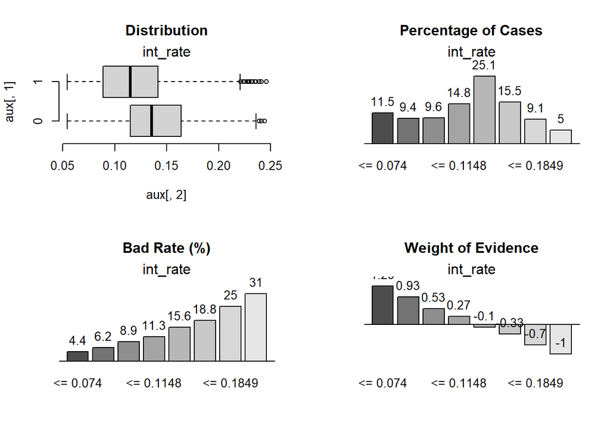

```r
variables_analysis("int_rate")
```

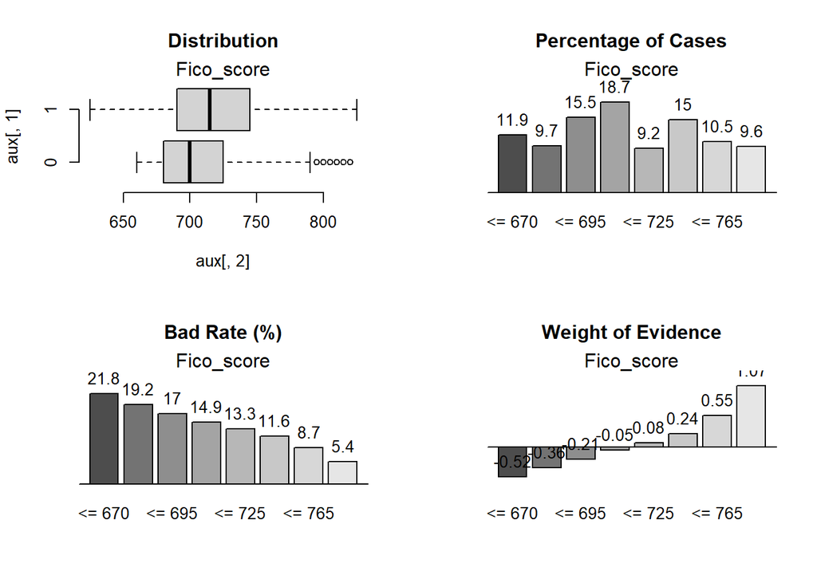

```r
variables_analysis("Fico_score")
```

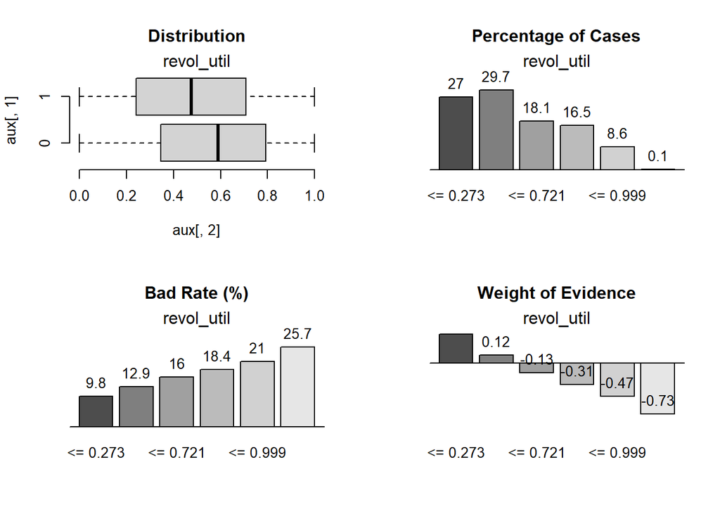

```r
variables_analysis("revol_util")
```

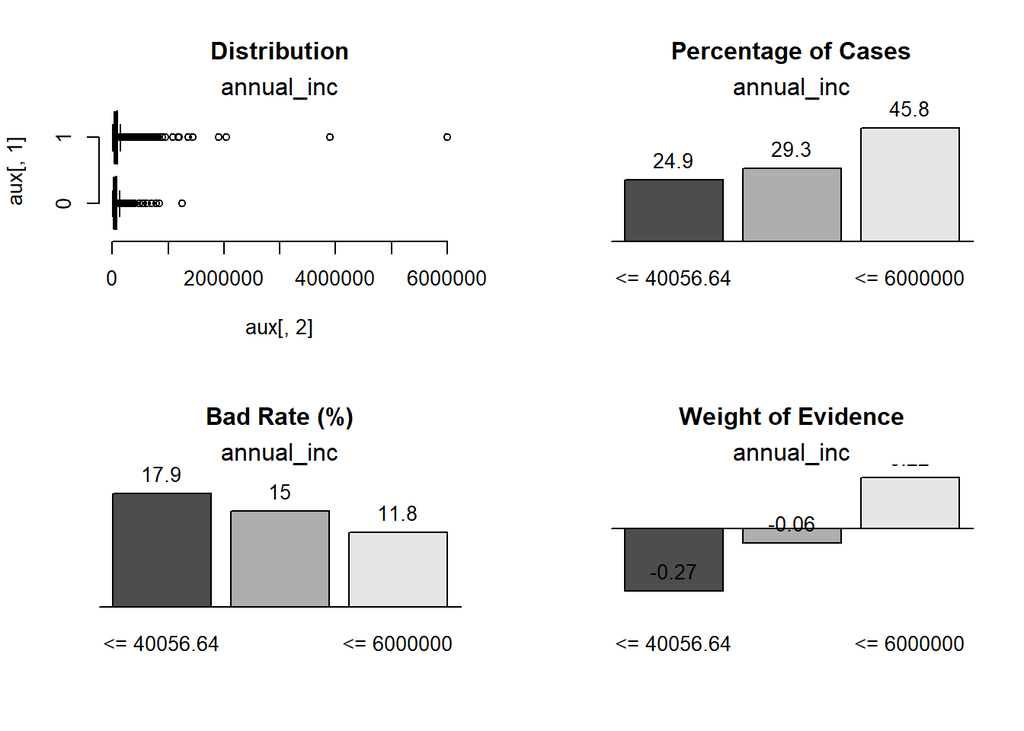

```r
variables_analysis("annual_inc")
```

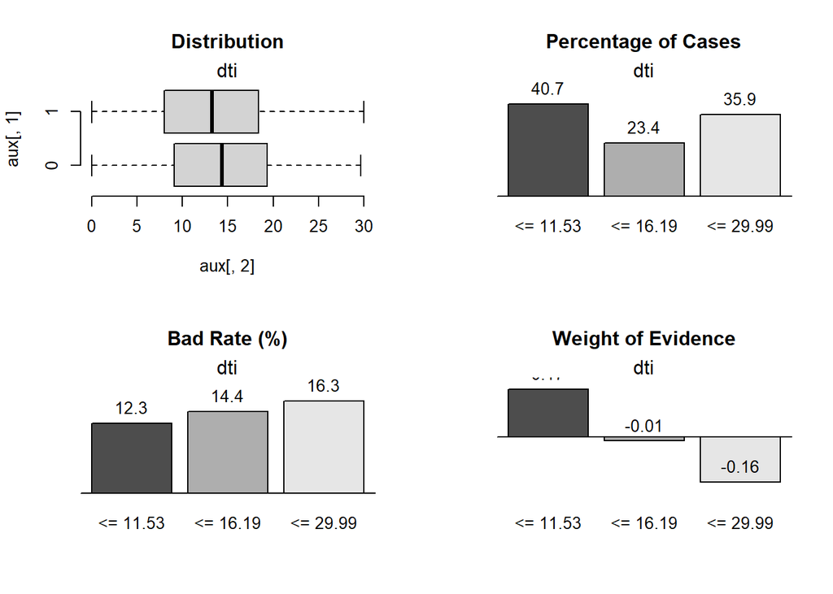

```r
variables_analysis("dti")
```

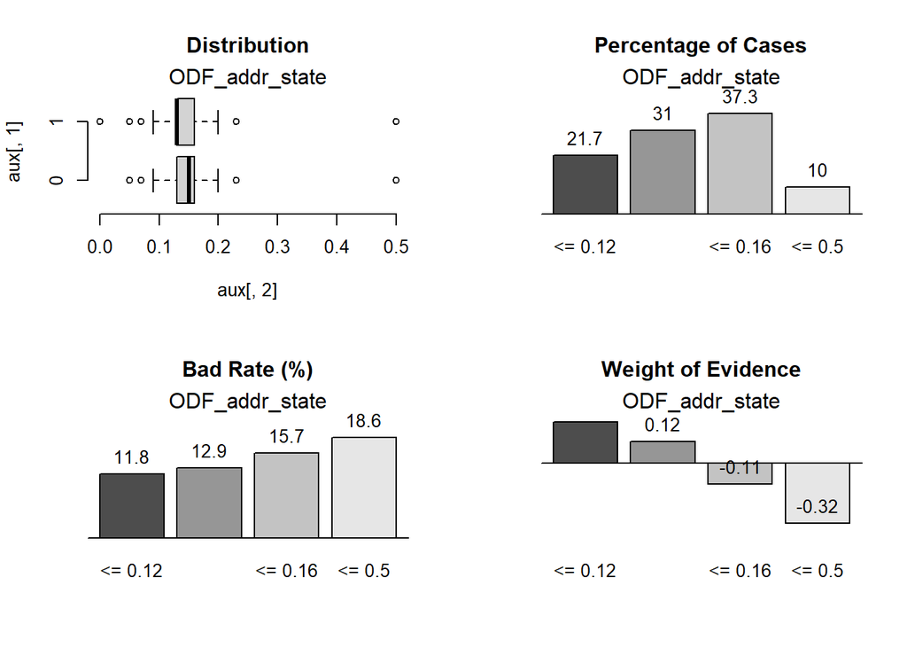

```r
variables_analysis("ODF_addr_state")
```

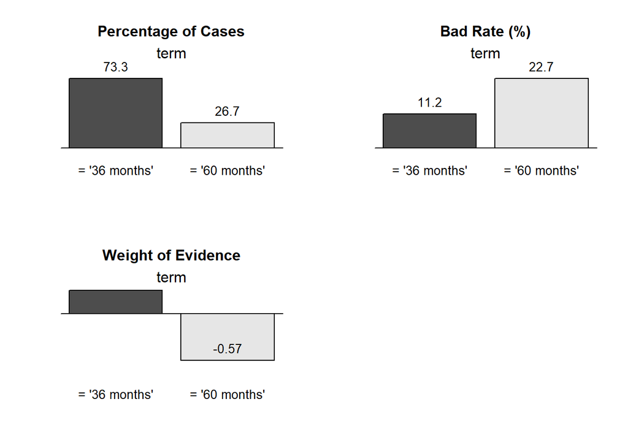

```r
variables_analysis("term")
variables_analysis("grade")
```

[figure not shown]

```r
variables_analysis("ODF_purpose")
```

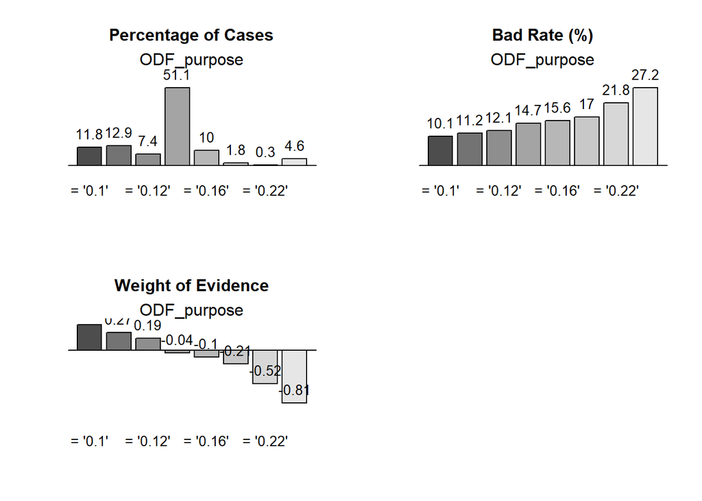

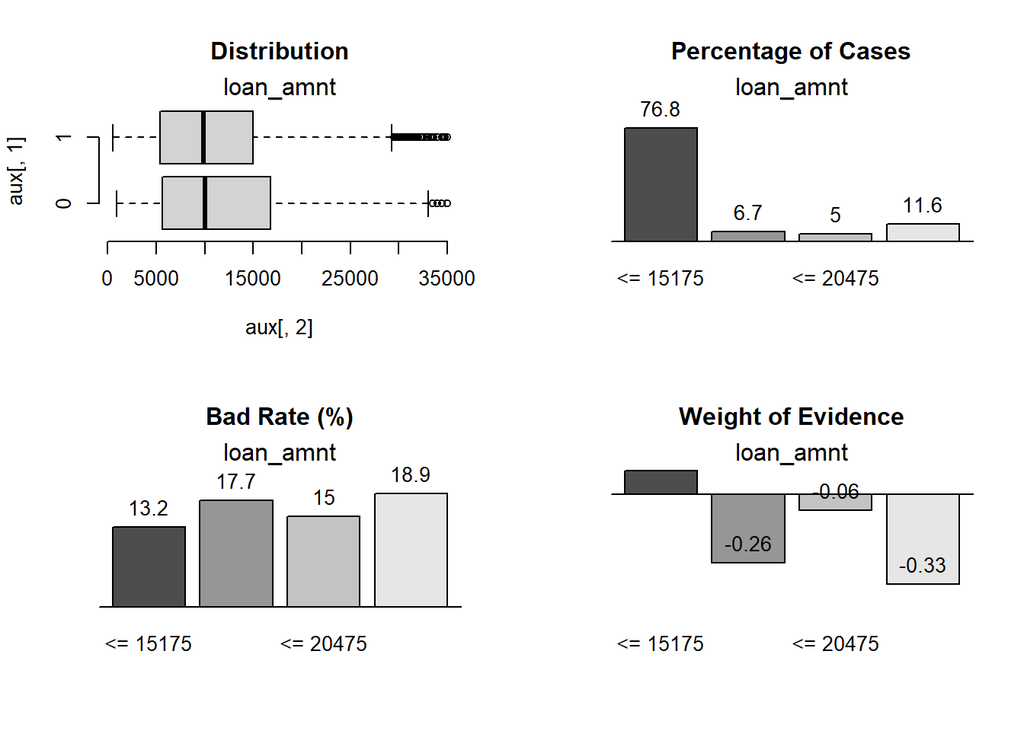

```r
variables_analysis("loan_amnt")
```

Como puede verse la variable loan_amnt parece comportarse de manera extraña o al menos poco intuitiva de explicar. Cuanto mayor es el importe del préstamo mayor es la tasa de default, aunque hay un tramo (de 15.175 a 20.475 euros) que parece comportarse mejor que el anterior grupo). Vamos a unir los dos grupos intermedios para conseguir esa monotonocidad. Creamos una variable loan_amnt2 que será la que usemos a partir de ahora:

```r
train$loan_amnt2<-as.factor(ifelse(train$loan_amnt<=15175,"<=15175",ifelse(train$loan_amnt<=20475,"<=20475",">20475")))

test$loan_amnt2<-as.factor(ifelse(test$loan_amnt<=15175,"<=15175",ifelse(test$loan_amnt<=20475,"<=20475",">20475")))
```

y vemos los resultados:

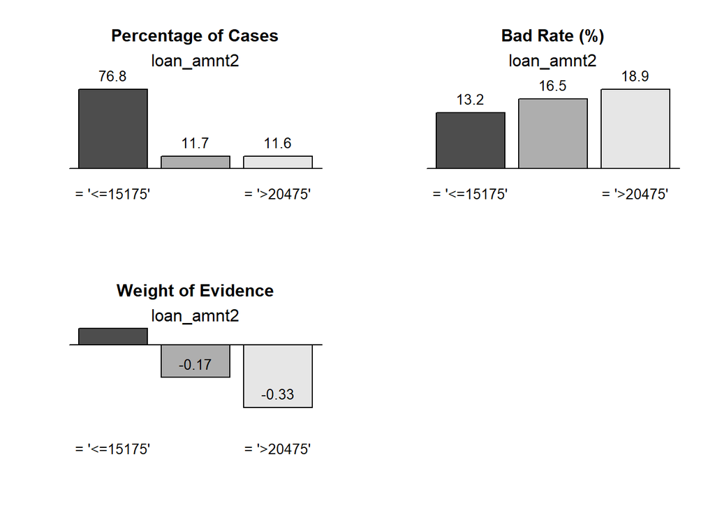

```r
variables_analysis("loan_amnt2")
```

Una vez que vemos que los grupos tienen sentido y que variables queremos emplear, realizamos el agrupamiento en las muestras, creando una nueva variable transformada para cada variable de entrada. Usaremos dos funciones:

```r
Groupping_numeric<-function(variable){

name<-as.character(variable)
aux_train<-train[,c("id","loan_status",name)]
aux_test<-test[,c("id","loan_status",name)]
colnames(aux_train)[3]<-"var_name"
colnames(aux_test)[3]<-"var_name"
aux_train$loan_status<-as.numeric(ifelse(train$loan_status==1,0,1))
aux_test$loan_status<-as.numeric(ifelse(test$loan_status==1,0,1))
groupping<-smbinning_calc(df=aux_train,y="loan_status",x="var_name",p=0.05)

table_woe<-as.data.frame(groupping$ivtable)
 for (i in 1:nrow(table_woe)){

   table_woe$ID[i]<-i

 }
table_woe$ID<-paste("0",table_woe$ID,sep='')


aux_train<-smbinning.gen(aux_train,groupping,"Bucket")
aux_train$ID<-substr(aux_train$Bucket,1,2)

aux_test<-smbinning.gen(aux_test,groupping,"Bucket")
aux_test$ID<-substr(aux_test$Bucket,1,2)


#table_woe$Bucket<-paste(row.names(table_woe),table_woe$Cutpoint,sep=' ')
#table_woe$Bucket<-paste("0",table_woe$Bucket,sep='')
table_woe<-table_woe[,c("ID","Cutpoint","WoE")]

aux_train<-merge(aux_train,table_woe,by.x=c("ID"),all.x=TRUE)
aux_train$Bucket<-NULL
aux_test<-merge(aux_test,table_woe,by.x=c("ID"),all.x=TRUE)
aux_test$Bucket<-NULL

miss_woe<-table_woe[grep("Missing",table_woe$Cutpoint),]

if (is.na(miss_woe$WoE)==FALSE){

value<- as.numeric(miss_woe$WoE)
#value<-as.numeric(gsub("NaN",0,value))

} else { value <-0 }

aux_train$WoE[is.na(aux_train$WoE)] <- value
aux_test$WoE[is.na(aux_test$WoE)] <- value

colnames(aux_train)[ncol(aux_train)]<-paste("WOE_",variable,sep='')
colnames(aux_test)[ncol(aux_test)]<-paste("WOE_",variable,sep='')

aux_train$sample<-"train"
aux_test$sample<-"test"

sample<-rbind(aux_train,aux_test)
sample<-sample[,c("id",paste("WOE_",variable,sep=''))]

return(sample)


}



Groupping_nominal<-function(variable){


name<-as.character(variable)
aux_train<-train[,c("id","loan_status",name)]
aux_test<-test[,c("id","loan_status",name)]
colnames(aux_train)[3]<-"var_name"
colnames(aux_test)[3]<-"var_name"
aux_train$loan_status<-as.numeric(ifelse(train$loan_status==1,0,1))
aux_test$loan_status<-as.numeric(ifelse(test$loan_status==1,0,1))
aux_train$var_name<-as.factor(aux_train$var_name)
aux_test$var_name<-as.factor(aux_test$var_name)
groupping<-smbinning.factor(df=aux_train,y="loan_status",x="var_name",maxcat = 8)

table_woe<-as.data.frame(groupping$ivtable)
 for (i in 1:nrow(table_woe)){

   table_woe$ID[i]<-i

 }
table_woe$ID<-paste("0",table_woe$ID,sep='')


aux_train<-smbinning.factor.gen(aux_train,groupping,"ID")

aux_test<-smbinning.factor.gen(aux_test,groupping,"ID")



table_woe$ID<-paste(table_woe$ID,table_woe$Cutpoint,sep=' ')

table_woe<-table_woe[,c("ID","Cutpoint","WoE")]

aux_train<-merge(aux_train,table_woe,by.x=c("ID"),all.x=TRUE)
aux_test<-merge(aux_test,table_woe,by.x=c("ID"),all.x=TRUE)


miss_woe<-table_woe[grep("Missing",table_woe$Cutpoint),]

if (is.na(miss_woe$WoE)==FALSE){

value<- as.numeric(miss_woe$WoE)
#value<-as.numeric(gsub("NaN",0,value))

} else { value <-0 }

aux_train$WoE[is.na(aux_train$WoE)] <- value
aux_test$WoE[is.na(aux_test$WoE)] <- value

colnames(aux_train)[ncol(aux_train)]<-paste("WOE_",variable,sep='')
colnames(aux_test)[ncol(aux_test)]<-paste("WOE_",variable,sep='')

aux_train$sample<-"train"
aux_test$sample<-"test"

sample<-rbind(aux_train,aux_test)
sample<-sample[,c("id",paste("WOE_",variable,sep=''))]

return(sample)


}
```

Hacemos el agrupamiento aplicando las funciones anteriores:

```r
train<-merge(train,Groupping_numeric("Fico_score"),by.x=c("id"))
train<-merge(train,Groupping_numeric("revol_util"),by.x=c("id"))
train<-merge(train,Groupping_numeric("annual_inc"),by.x=c("id"))
train<-merge(train,Groupping_numeric("dti"),by.x=c("id"))
train<-merge(train,Groupping_numeric("ODF_addr_state"),by.x=c("id"))
train<-merge(train,Groupping_nominal("grade"),by.x=c("id"))
train<-merge(train,Groupping_nominal("term"),by.x=c("id"))
train<-merge(train,Groupping_nominal("ODF_purpose"),by.x=c("id"))
train<-merge(train,Groupping_nominal("loan_amnt2"),by.x=c("id"))
train<-merge(train,Groupping_nominal("flag_cliente"),by.x=c("id"))

test<-merge(test,Groupping_numeric("Fico_score"),by.x=c("id"))
test<-merge(test,Groupping_numeric("revol_util"),by.x=c("id"))
test<-merge(test,Groupping_numeric("annual_inc"),by.x=c("id"))
test<-merge(test,Groupping_numeric("dti"),by.x=c("id"))
test<-merge(test,Groupping_numeric("ODF_addr_state"),by.x=c("id"))
test<-merge(test,Groupping_nominal("grade"),by.x=c("id"))
test<-merge(test,Groupping_nominal("term"),by.x=c("id"))
test<-merge(test,Groupping_nominal("ODF_purpose"),by.x=c("id"))
test<-merge(test,Groupping_nominal("loan_amnt2"),by.x=c("id"))
test<-merge(test,Groupping_nominal("flag_cliente"),by.x=c("id"))
```

Vemos las nuevas variables creadas en las muestras:

```r
colnames(train)
```

```
##  [1] "id"                     "purpose"                "addr_state"
##  [4] "loan_amnt"              "term"                   "int_rate"
##  [7] "installment"            "grade"                  "emp_title"
## [10] "emp_length"             "home_ownership"         "annual_inc"
## [13] "verification_status"    "issue_d"                "loan_status"
## [16] "desc"                   "dti"                    "delinq_2yrs"
## [19] "Fico_score"             "inq_last_6mths"         "mths_since_last_delinq"
## [22] "mths_since_last_record" "open_acc"               "revol_bal"
## [25] "revol_util"             "ant_cliente"            "flag_cliente"
## [28] "Default2"               "ODF_addr_state"         "ODF_purpose"
## [31] "loan_amnt2"             "WOE_Fico_score"         "WOE_revol_util"
## [34] "WOE_annual_inc"         "WOE_dti"                "WOE_ODF_addr_state"
## [37] "WOE_grade"              "WOE_term"               "WOE_ODF_purpose"
## [40] "WOE_loan_amnt2"         "WOE_flag_cliente"
```

```r
colnames(test)
```

```
##  [1] "id"                     "purpose"                "addr_state"
##  [4] "loan_amnt"              "term"                   "int_rate"
##  [7] "installment"            "grade"                  "emp_title"
## [10] "emp_length"             "home_ownership"         "annual_inc"
## [13] "verification_status"    "issue_d"                "loan_status"
## [16] "desc"                   "dti"                    "delinq_2yrs"
## [19] "Fico_score"             "inq_last_6mths"         "mths_since_last_delinq"
## [22] "mths_since_last_record" "open_acc"               "revol_bal"
## [25] "revol_util"             "ant_cliente"            "flag_cliente"
## [28] "Default2"               "ODF_addr_state"         "ODF_purpose"
## [31] "loan_amnt2"             "WOE_Fico_score"         "WOE_revol_util"
## [34] "WOE_annual_inc"         "WOE_dti"                "WOE_ODF_addr_state"
## [37] "WOE_grade"              "WOE_term"               "WOE_ODF_purpose"
## [40] "WOE_loan_amnt2"         "WOE_flag_cliente"
```

```r
save.image("Backup4.RData")
```

EJERCICIO 4: ESTIMACIÓN DEL MODELO

Aunque se ha realizado el análisis individual de cada variable ahora debemos combinarlas para que consigan separar a los clientes buenos de los malos de la mejor manera posible. Se pretende que los modelos sean parsimoniosos, es decir con el menor número posible de variables, para que sea comprensible y, por otro lado que no tenga variables correlacionadas. Vamos a ver las correlaciones existentes:

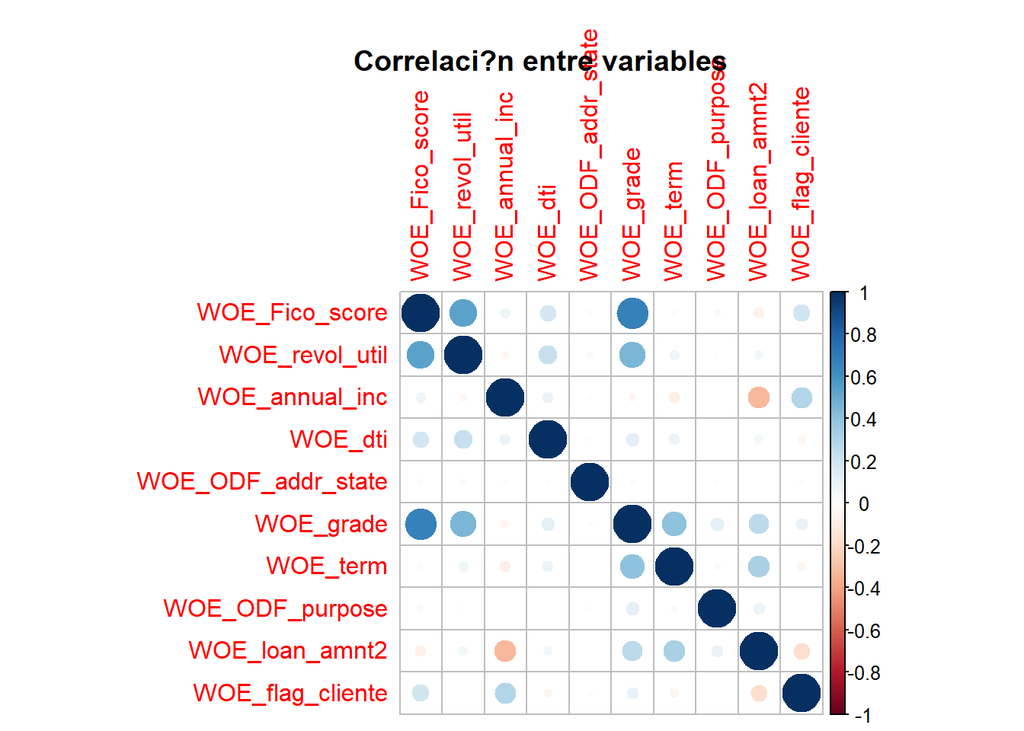

```r
rm(list=setdiff(ls(), c("Loans","train","test")))

variables_relevantes<-names(train[,32:41])

# Correlation matrix

correlations<-cor(train[, variables_relevantes], use="pairwise", method="pearson")

corrplot(correlations, mar=c(0,0,1,0))
title(main="Correlaci?n entre variables")
```

como se puede apreciar no hay una correlación muy elevada entre las variables, la variable que más correlación presenta es el Fico Score con el grade o calificación que proporciona LendingClub:

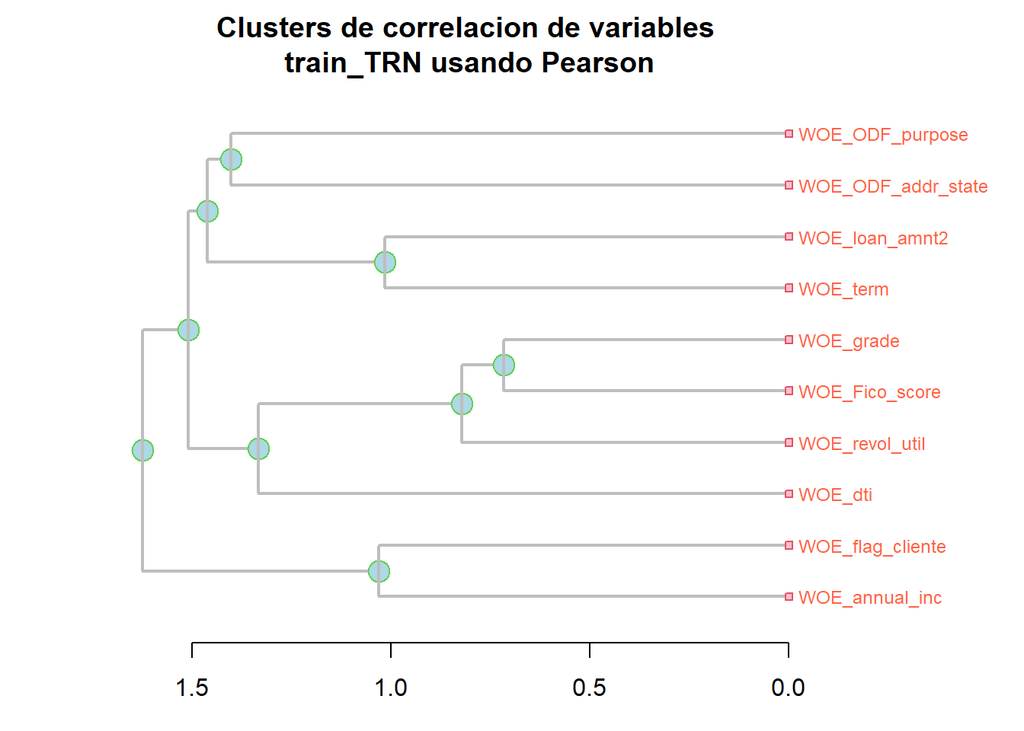

```r
# Generar un cl?ster jer?rquico de variables.

hc <- hclust(dist(correlations), method="average")

# Generar el dendrograma.

dn <- as.dendrogram(hc)

op <- par(mar = c(3, 4, 3, 7.14))
plot(dn, horiz = TRUE, nodePar = list(col = 3:2, cex = c(2.0, 0.75), pch = 21:22, bg=  c("light blue", "pink"), lab.cex = 0.75, lab.col = "tomato"), edgePar = list(col = "gray", lwd = 2), xlab="Height")
title(main="Clusters de correlacion de variables
 train_TRN usando Pearson")
```

```r
par(op)
```

Las correlaciones entre variables no estarían correctamente calculadas ya que lo que tenemos ahora son trasnformaciones de la variable a 4 o 5 valores máximo en media, lo cual aumenta las probabilidades de correlación entre variables).

Por este motivo es más recomendable el uso de la V de Cramer como medida de asociación entre las variables:

```r
get.V<-function(y){
  library(vcd)
  col.y<-ncol(y)
  V<-matrix(ncol=col.y,nrow=col.y)
  for(i in 1:col.y){
    for(j in 1:col.y){
      V[i,j]<-assocstats(table(y[,i],y[,j]))$cramer
    }
  }
  return(V)
}


Cramer_corr<-get.V(train[,variables_relevantes])
colnames(Cramer_corr)<-colnames(train[,variables_relevantes])
rownames(Cramer_corr)<-colnames(train[,variables_relevantes])
```

Se considera que dos variables estan altamente correladas si tienen una V de Cramer superior a 0.4:

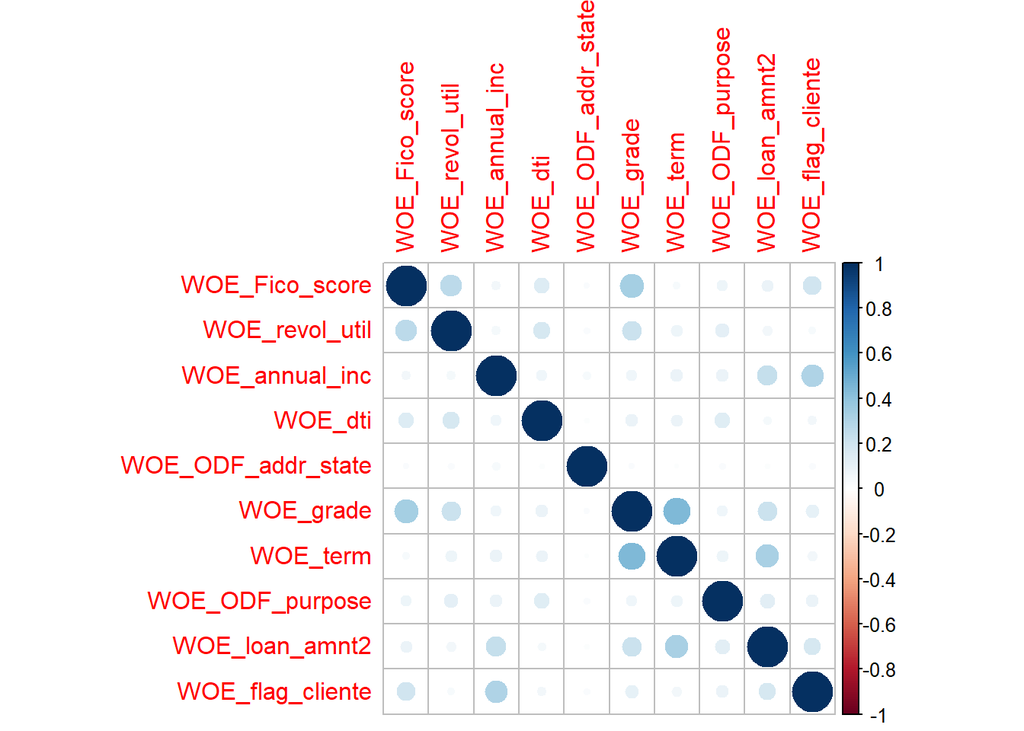

```r
corrplot(Cramer_corr)
```

Vamos a pasar a hacer diferentes modelos para ver cuál sería nuestro modelo elegido. Al tener 9 variables (el grade lo excluiremos) tendríamos la posibilidad de realizar 2^9 -1 modelos diferentes.

Normalmente, como contamos con un número más elevado de variables no calculamos todos los modelos. En estos casos empleamos una técnica denominada Branch and Bound, que permite calcular los mejores modelos sin necesidad de llevar a cabo cada uno de ellos por separado.

El paquete que permite hacer este procedimiento en R requiere de rJava y en ocasiones no funciona en todos los ordenadores que hemos probado, sobretodo en los ordenadores de empresa donde hay más problemas de permisos.

Por este motivo vamos a calcular todos los modelos posibles esta vez. Para esto vamos a realizar todas las combinaciones de variables solamente de 8 variables (interpretemos que los analistas o el MO del modelo no quiere modelos ni de más ni de menos variables)

Además de hacer las combinaciones, vamos a calcular cuál es el poder predictivo de cada modelo sobre cada una de las muestras (train and test) y vamos a omitir modelos con variables correlacionadas o cuyo coeficiente o signo en el modelo sea contrario a lo esperado:

```r
combinations<-function(variables,comb){

d <- combn(variables,comb) # All combinations 2 variables
d <-as.data.frame(t(d))

for (i in 1:nrow(d)){

  d$id[i]<-paste(comb,"_",i,sep='')
}

return(d)
}

variables<-names(train[,variables_relevantes])



combinats8<-combinations(variables,8)



hacer_modelos<-function(modelos){

lista<-as.data.frame(modelos)
temp<-matrix("NA",0,5)
temp<-as.data.frame(temp)
colnames(temp)<-c("id","Gini_train","Gini_test","test_signos","test_correlaciones")


for (j in 1:(nrow(lista))){


aux<-as.data.frame((as.data.frame(lista[j,])))

for (i in 1:(ncol(aux))){


colnames(aux)[i]<-as.character(aux[1,i])

}

ind<-names(aux[,1:ncol(aux)-1])
temp2<-matrix("NA",1,5)
temp2[1,1]<-lista[j,"id"]
rm(aux)


Logit_model <- glm(loan_status ~ ., data=train[, c("loan_status",ind)],
    family=binomial(link="logit"))

pr_logit_train <- predict(Logit_model, type="response", newdata=train[, c("loan_status",ind)])

pred <- prediction(pr_logit_train, train$loan_status)
pe_Logit <- performance(pred, "tpr", "fpr")
au_Logit <- performance(pred, "auc")@y.values[[1]]

temp2[1,2]<-as.numeric(round(2*au_Logit-1,4))


pr_logit_test <- predict(Logit_model, type="response", newdata=test[, c("loan_status",ind)])

pred <- prediction(pr_logit_test, test$loan_status)
pe_Logit <- performance(pred, "tpr", "fpr")
au_Logit <- performance(pred, "auc")@y.values[[1]]

temp2[1,3]<-as.numeric(round(2*au_Logit-1,4))


coeficientes<-as.data.frame(Logit_model$coefficient)
coeficientes<-as.data.frame(coeficientes[coeficientes[,1]!="(Intercept)",])
temp2[1,4]<-ifelse(max(coeficientes)<0,1,0)

Correlations<-get.V(train[,ind])
diag(Correlations)<-0
test_cor<-ifelse(abs(max(Correlations))<0.4,1,0)
temp2[1,5]<-test_cor
colnames(temp2)<-colnames(temp)
temp<-rbind(temp,temp2)
rm(temp2)
print("Modelo")
print(j)
print("de")
print(nrow(lista))
}
return(temp)
}
```

Procedemos a realizar los modelos (puede llevar algo de tiempo):

```r
t <- proc.time()

modelos8<-hacer_modelos(combinats8)
proc.time()-t

#resultadosModelos<-rbind(modelos6,modelos7,modelos8)
resultadosModelos<-modelos8
head(resultadosModelos)

save.image("Backup5.RData")
```

Vamos a filtrar los modelos que no cumplen las restricciones de signo negativo de los coeficientes (al hacerse la transformación a Woes todos los valores deberían venir en negativo) y de correlaciones, es decir las variables del modelo no deberían estar correlacionadas:

```r
resultadosModelos<-resultadosModelos[resultadosModelos$test_signos==1 & resultadosModelos$test_correlaciones==1,]

resultadosModelos$Gini_train<-as.numeric(as.character(resultadosModelos$Gini_train))
resultadosModelos$Gini_test<-as.numeric(as.character(resultadosModelos$Gini_test))

resultadosModelos<-resultadosModelos[order(-resultadosModelos$Gini_train),]
```

Seleccionamos el mejor modelo:

```r
resultadosModelos<-head(resultadosModelos,1)
resultadosModelos
```

```
##    id Gini_train Gini_test test_signos test_correlaciones
## 7 8_7       0.39      0.36           1                  1
```

Vamos a ver que variables están dentro del modelo:

```r
best_model<-merge(resultadosModelos,combinats8,by.x="id")
t(best_model[,6:13])
```

```
##    [,1]
## V1 "WOE_Fico_score"
## V2 "WOE_revol_util"
## V3 "WOE_annual_inc"
## V4 "WOE_dti"
## V5 "WOE_ODF_addr_state"
## V6 "WOE_term"
## V7 "WOE_ODF_purpose"
## V8 "WOE_loan_amnt2"
```

Estimemos el modelo para ver los coeficientes:

```r
variables<-c("WOE_Fico_score","WOE_revol_util","WOE_annual_inc","WOE_ODF_addr_state","WOE_term","WOE_ODF_purpose","WOE_loan_amnt2")

Best_Logit_Model <- glm(loan_status ~ ., data=train[, c("loan_status",variables)],
    family=binomial(link="logit"))

summary(Best_Logit_Model)
```

```
##
## Call:
## glm(formula = loan_status ~ ., family = binomial(link = "logit"),
##     data = train[, c("loan_status", variables)])
##
## Deviance Residuals:
##    Min      1Q  Median      3Q     Max
## -1.480  -0.596  -0.463  -0.325   2.772
##
## Coefficients:
##                    Estimate Std. Error z value             Pr(>|z|)
## (Intercept)         -1.7996     0.0183  -98.59 < 0.0000000000000002 ***
## WOE_Fico_score      -0.8577     0.0540  -15.89 < 0.0000000000000002 ***
## WOE_revol_util      -0.4136     0.0685   -6.04     0.00000000157039 ***
## WOE_annual_inc      -1.3959     0.0946  -14.76 < 0.0000000000000002 ***
## WOE_ODF_addr_state  -0.9459     0.1028   -9.20 < 0.0000000000000002 ***
## WOE_term            -0.9391     0.0455  -20.66 < 0.0000000000000002 ***
## WOE_ODF_purpose     -0.9737     0.0670  -14.54 < 0.0000000000000002 ***
## WOE_loan_amnt2      -0.9388     0.1288   -7.29     0.00000000000032 ***
## ---
## Signif. codes:  0 '***' 0.001 '**' 0.01 '*' 0.05 '.' 0.1 ' ' 1
##
## (Dispersion parameter for binomial family taken to be 1)
##
##     Null deviance: 22813  on 27849  degrees of freedom
## Residual deviance: 21166  on 27842  degrees of freedom
## AIC: 21182
##
## Number of Fisher Scoring iterations: 5
```

```r
save.image("Backup6.RData")
```

EJERCICIO 5: PUNTOS DE CORTE

Podemos asignar una probabilidad de acuerdo a nuestro modelo para cada solicitante de nuestras muestras:

```r
options(digits=4)

PD <- predict(Best_Logit_Model, type="response", newdata=train[, c("loan_status",variables)])

# print(PD)

Predictions_Logit<-cbind(train,PD)
```

Vamos a transforman nuestro modelo en una tarjeta de puntuación, donde tener 500 puntos implicaría tener una probabilidad de incumpliento del 50%. Es decir existe un mal cliente por cada uno bueno.

Además, cada 20 puntos, se doblan los odds, es decir en los 520 puntos habría 2 clientes buenos por cada uno malo.

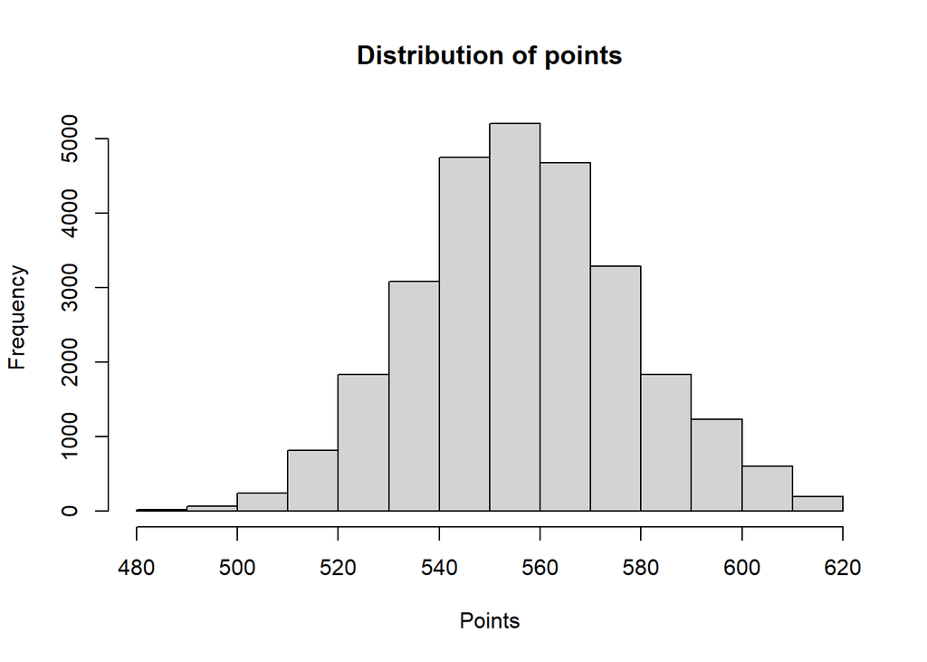

```r
Puntos<-500
Odds<-1
Puntos_doblar_odds<-20

Factor<-Puntos_doblar_odds/log(2)

Offset<-Puntos-(Factor*log(Odds))

Predictions_Logit$Points<-round(Offset+(log((1-PD)/PD))*Factor,0)

hist(Predictions_Logit$Points,main="Distribution of points",xlab="Points")
```

Imaginaros que el modelo antiguo, el cuál será remplazado por este modelo, aprueba automáticamente el 80% de las solicitudes de préstamos con un bad rate del 15%.

Vamos a partir nuestro dataset en 20 puntos de corte de puntuación y analizamos como podemos usar este modelo para sustituir al modelo teórico anterior y además controlar el % de admisión y la tasa de incumplimiento esperada:

```r
Predictions_Logit$bins <- cut(Predictions_Logit$Points, 20, include.lowest=TRUE)

aux<-sqldf("SELECT bins,
      sum(loan_status) as DEFAULTS,
      count(loan_status) as N,
      avg(PD) as Avg_pred_PD
      from Predictions_Logit group by bins")

aux$FDO<-aux$DEFAULTS/aux$N

for (i in 1:nrow(aux)){
  ifelse(i==1,aux$N_acum[i]<-aux$N[i],aux$N_acum[i]<-aux$N[i]+aux$N_acum[i-1])
  ifelse(i==1,aux$Def_acum[i]<-aux$DEFAULTS[i],aux$Def_acum[i]<-aux$DEFAULTS[i]+aux$Def_acum[i-1])

}

aux$aceptance_above<-1-(aux$N_acum/sum(aux$N))
defaults<-sum(aux$DEFAULTS)
registros<-nrow(Predictions_Logit)

aux$defaults_above<-(defaults-aux$Def_acum)/registros

aux<-aux[,c("bins","aceptance_above","defaults_above")]
aux2<-sqldf("SELECT bins,
      max(PD) as PD_superior,
      max(Points) as Points_superior
      from Predictions_Logit group by bins")

aux<-merge(aux,aux2,by.x="bins")
```

En base a la información anterior nos planteamos una serie de preguntas:

1- Si queremos mantener la misma tasas de aceptación actual, ¿cuál sería el punto de corte que propondríais?

2- Y si queremos mantener la misma tasa de defaults como hasta ahora, ¿qué punto de corte podría establecerse?

```r
muestra_desarrollo<-cbind(train,Predictions_Logit[,42:44])
rm(list=setdiff(ls(), "muestra_desarrollo"))

save.image("Backup7.RData")
```

EJERCICIO 6: MUESTRAS OOT AND TTD

```r
library(Hmisc)

OOT_sample <- read.csv("OOT_sample.csv", stringsAsFactors=FALSE)

unique(OOT_sample$issue_d)
```

```
## [1] "6/1/2012"
```

```r
print("El poder predictivo del modelo en la muestra de desarrollo era:")
```

```
## [1] "El poder predictivo del modelo en la muestra de desarrollo era:"
```

```r
(2*rcorr.cens(muestra_desarrollo$PD,muestra_desarrollo$loan_status)[1])-1
```

```
## C Index
##  0.3875
```

```r
print("El poder predictivo del modelo en la muestra OOT es:")
```

```
## [1] "El poder predictivo del modelo en la muestra OOT es:"
```

```r
(2*rcorr.cens(OOT_sample$PD,OOT_sample$loan_status)[1])-1
```

```
## C Index
##  0.3702
```

Parece que el poder predictivo en una muestra un poco mas reciente a la que se desarrollo el modelo, parece seguir siendo valido. Podemos evaluar si hay signos de fatiga en el modelo o de que no vaya a funcionar bien en una muestra todav?a mas reciente pero en la que aun no hay desempeño, es decir no podemos ver cual es el resultado de pago impago de los prestamos.

Se analiza solamente la estabilidad a traves de la metrica PSI Population Stability Index. Valores entre 0.1 y 0.25 indican que se ha producido una variacion leve en la distribucion de la poblacion en comparacion con la muestra de desarrollo. VAlores m?s altos que 0.25 indican que la distribucion de la poblacion para esa variable se ha modificado drasticamente.

Primero cargamos nuestra muestra TTD:

```r
TTD_sample <- read.csv("TTD_sample.csv", stringsAsFactors=FALSE)

unique(TTD_sample$issue_d)
```

```
## [1] "6/1/2013"
```

```r
psi<-function(muestra_des,muestra_actual,variable){

a1<-data.frame(table(muestra_des[,c(variable)]))
a2<-data.frame(table(muestra_actual[,c(variable)]))

a3<-merge(a1,a2,by=c("Var1"))
colnames(a3)<-c(var,"des","actual")
a3$perc_des<-a3$des/sum(a3$des)
a3$perc_actual<-a3$actual/sum(a3$actual)
a3$psi_index<-(a3$perc_actual-a3$perc_des)*log(a3$perc_actual/a3$perc_des)
psi<-sum(a3$psi_index)

return(psi)

}

# ggplot(a3, aes(length, fill = veg)) + geom_density(alpha = 0.2)
```

```r
#
# muestra_des <- muestra_desarrollo
# muestra_actual <- TTD_sample
# variable <- "WOE_revol_util"
#
# a1<-data.frame(table(muestra_des[,c(variable)]))
# a2<-data.frame(table(muestra_actual[,c(variable)]))
#
# a3<-merge(a1,a2,by=c("Var1"))
# colnames(a3)<-c("var","des","actual")
# a3$perc_des<-a3$des/sum(a3$des)
# a3$perc_actual<-a3$actual/sum(a3$actual)
# a3$psi_index<-(a3$perc_actual-a3$perc_des)*log(a3$perc_actual/a3$perc_des)
# psi_value<-sum(a3$psi_index)
# psi_value
```

Vamos a calcular el PSI para todas las variables del modelo:

```r
print("WOE_Fico_score:")
```

```
## [1] "WOE_Fico_score:"
```

```r
psi(muestra_desarrollo,TTD_sample,"WOE_Fico_score")
```

```
## [1] 0.1039
```

```r
print("WOE_revol_util:")
```

```
## [1] "WOE_revol_util:"
```

```r
psi(muestra_desarrollo,TTD_sample,"WOE_revol_util")
```

```
## [1] 0.2677
```

```r
print("WOE_annual_inc:")
```

```
## [1] "WOE_annual_inc:"
```

```r
psi(muestra_desarrollo,TTD_sample,"WOE_annual_inc")
```

```
## [1] 0.00347
```

```r
print("WOE_ODF_addr_state:")
```

```
## [1] "WOE_ODF_addr_state:"
```

```r
psi(muestra_desarrollo,TTD_sample,"WOE_ODF_addr_state")
```

```
## [1] 0.005697
```

```r
print("WOE_term:")
```

```
## [1] "WOE_term:"
```

```r
psi(muestra_desarrollo,TTD_sample,"WOE_term")
```

```
## [1] 0.04987
```

```r
print("WOE_ODF_purpose:")
```

```
## [1] "WOE_ODF_purpose:"
```

```r
psi(muestra_desarrollo,TTD_sample,"WOE_ODF_purpose")
```

```
## [1] 0.167
```

```r
print("WOE_loan_amnt2:")
```

```
## [1] "WOE_loan_amnt2:"
```

```r
psi(muestra_desarrollo,TTD_sample,"WOE_loan_amnt2")
```

```
## [1] 0.06478
```